# MD 9 Preview Season 2627

Result

| Arsenal Konsa 7' Magalhães 68' | 2 – 0 | Everton — |
| --- | --- | --- |

Arsenal vs Everton - 24-10-2026 | Premier League MD 8

Arsenal beat Everton 2–0 with the better of the xG (1.98 vs 0.63). Arsenal's peak field tilt was 85% in the 2nd Quarter. Everton's peak field tilt was 58% in the 4th Quarter.

xG

ARS 1.98 – 0.63 EVE

xGOT

ARS 2.26 – 0.49 EVE

Field Tilt %

ARS 65% – 35% EVE

PPDA (lower = more intense press)

ARS 10.16 – 16.94 EVE

EPV

ARS 3.46 – 1.73 EVE

EPV to xG Conversion %

ARS 57% – 36% EVE

xG Race

[figure not shown]

Match Momentum

[figure not shown]

Threat Race

[figure not shown]

Field Tilt Momentum

[figure not shown]

Match Report

Summary

- Arsenal beat Everton 2–0 with the better of the xG (1.98 vs 0.63). Arsenal's peak field tilt was 85% in the 2nd Quarter. Everton's peak field tilt was 58% in the 4th Quarter.

Set pieces

- **Arsenal** took 12 corners (1 short), winning first contact on 3 of 11 direct deliveries. Set pieces produced 6 shots worth 0.91 xG and 1 goal (46% of their xG).

- **Everton** took 3 corners, winning first contact on 0 of 3 direct deliveries. Set pieces produced 0 shots worth 0.00 xG (0% of their xG).

Transitions

- **Arsenal** won the ball in open play 73 times (13 in the attacking third) and had 3 shots within 15 seconds of a regain, worth 0.31 xG including 1 goal (Konsa 7').

- **Everton** won the ball in open play 78 times (6 in the attacking third) and had 5 shots within 15 seconds of a regain, worth 0.49 xG.

Defensive shape

- **Everton**'s defensive actions dropped from an average of 36.9m to 19.1m from their own goal between the 1st Quarter and the 2nd Quarter (score 1-0 at the start of the 2nd Quarter), while **Arsenal** went from 39.8m to 54.6m over the 3rd Quarter to 4th Quarter. Standard PPDA: Arsenal 10.16, Everton 16.94 (lower = more pressing).

Passing chains

- **Arsenal** strung together 16 moves of 10+ completed passes (51% of their completed passes came in those moves, 1 ended in a shot). Their longest move was 26 passes (90+1').

- **Everton** strung together 9 moves of 10+ completed passes (46% of their completed passes came in those moves, 2 ended in a shot). Their longest move was 34 passes (77').

Threat areas

- **Arsenal** generated most threat from the final third, left wing (0.75 EPV, 22%), followed by the final third, right half-space (0.57).

- **Everton** generated most threat from the final third, left wing (0.31 EPV, 18%), followed by the defensive third, central (0.17).

Pass maps

- **Arsenal**'s most used combination was White to Ødegaard (19 completed passes), and Ødegaard was the hub of the pass map, involved in 177 completed passes.

- **Everton**'s most used combination was Pickford to Tarkowski (11 completed passes), and Tarkowski was the hub of the pass map, involved in 75 completed passes.

Arsenal Line up

Arsenal vs Everton - 24-10-2026

| Mins Played | Shirt Number | Player |
| --- | --- | --- |
| Keeper |  |  |
| 101 | 1 | David Raya |
| Defender |  |  |
| 101 | 4 | Ben White |
| 101 | 15 | Ezri Konsa |
| 101 | 6 | Gabriel Magalhães |
| 70 | 49 | Myles Lewis-Skelly |
| 31 | 33 | Riccardo Calafiori |
| Midfielder |  |  |
| 101 | 8 | Martin Ødegaard |
| 101 | 20 | Noni Madueke |
| 82 | 41 | Declan Rice |
| 82 | 10 | Eberechi Eze |
| 70 | 23 | Mikel Merino |
| 31 | 39 | Bruno Guimarães |
| 19 | 36 | Martín Zubimendi |
| 19 | 56 | Max Dowman |
| Forward |  |  |
| 70 | 14 | Viktor Gyökeres |
| 31 | 29 | Kai Havertz |
| Substitute |  |  |
| 0 | 13 | Kepa Arrizabalaga |
| 0 | 3 | Cristhian Mosquera |
| 0 | 5 | Piero Hincapié |
| 0 | 12 | Jurriën Timber |

X @Barts78 · Bluesky @barts78 · Mastodon @DrBarts · GitHub Barts78 · LinkedIn Phil-barter · Data: Opta

Everton Line up

Arsenal vs Everton - 24-10-2026

|  | Shirt Number | Mins Played |
| --- | --- | --- |
| Keeper |  |  |
| Jordan Pickford | 1 | 101 |
| Defender |  |  |
| Jake O'Brien | 15 | 101 |
| James Tarkowski | 6 | 101 |
| Merlin Röhl | 34 | 101 |
| Vitalii Mykolenko | 16 | 76 |
| Midfielder |  |  |
| Harrison Armstrong | 45 | 101 |
| James Garner | 37 | 101 |
| Tyrique George | 19 | 101 |
| Kiernan Dewsbury-Hall | 8 | 88 |
| Brennan Johnson | 22 | 74 |
| Tyler Dibling | 20 | 27 |
| Hayden Hackney | 30 | 25 |
| Charly Alcaraz | 24 | 13 |
| Forward |  |  |
| Thierno Barry | 11 | 101 |
| Substitute |  |  |
| Mark Travers | 12 | 0 |
| Tom King | 31 | 0 |
| Ainsley Maitland-Niles | 2 | 0 |
| Michael Keane | 5 | 0 |
| Christian Nørgaard | 23 | 0 |
| Braiden Graham | 58 | 0 |

X @Barts78 · Bluesky @barts78 · Mastodon @DrBarts · GitHub Barts78 · LinkedIn Phil-barter · Data: Opta

**Match Summary tables**

**Match Summary - Full Time**

Arsenal vs Everton - 24-10-2026

| Possession Possession % | Possession On Ball Time | Possession Touches | Possession PKBox Touches | Possession Field Tilt % | Shots Total Shots | Shots OFF Shots | Shots SoT | Shots 6yrd box Shots | Shots PK Box Shots | Shots Outside Box Shots | Shots Blocked Shots | Shots BCs | Shots Goals | Shots xG | Shots NPxG | Shots xGOT | Threat EPV | Threat EPV % xG Con. | Threat EPV % NPxG Con. | Passes Attempted Passes | Passes Successful Passes | Passes Pass Success % | Passes Long Passes | Passes Long Ball Rate | Passes Crosses | Passes Cross Success % | Passes Corners | Passes Short Corners | PPDO | … |
| --- | --- | --- | --- | --- | --- | --- | --- | --- | --- | --- | --- | --- | --- | --- | --- | --- | --- | --- | --- | --- | --- | --- | --- | --- | --- | --- | --- | --- | --- | --- |
| Arsenal |  |  |  |  |  |  |  |  |  |  |  |  |  |  |  |  |  |  |  |  |  |  |  |  |  |  |  |  |  | … |
| 55.9% | 41.00 | 718 | 48 | 64.9% | 20 | 6 | 4 | 5 | 12 | 8 | 10 | 3 | 2 | 1.98 | 1.98 | 2.26 | 3.46 | 57.2% | 57.2% | 518 | 449 | 86.7% | 36 | 7.0% | 23 | 21.7% | 12 | 1 |  | … |
| Everton |  |  |  |  |  |  |  |  |  |  |  |  |  |  |  |  |  |  |  |  |  |  |  |  |  |  |  |  |  | … |
| 44.1% | 37.20 | 567 | 18 | 35.1% | 8 | 3 | 3 | 0 | 6 | 2 | 2 | 2 | 0 | 0.63 | 0.63 | 0.49 | 1.73 | 36.4% | 36.4% | 372 | 317 | 85.2% | 48 | 12.9% | 16 | 12.5% | 3 | 0 | 500 | … |

X @Barts78 · Bluesky @barts78 · Mastodon @DrBarts · GitHub Barts78 · LinkedIn Phil-barter · Data: Opta

**Match Summary - By Half**

Arsenal vs Everton - 24-10-2026

|  | Possession Possession % | Possession On Ball Time | Possession Touches | Possession PKBox Touches | Possession Field Tilt % | Shots Total Shots | Shots OFF Shots | Shots SoT | Shots 6yrd box Shots | Shots PK Box Shots | Shots Outside Box Shots | Shots Blocked Shots | Shots BCs | Shots Goals | Shots xG | Shots NPxG | Shots xGOT | Threat EPV | Threat EPV % xG Con. | Threat EPV % NPxG Con. | Passes Attempted Passes | Passes Successful Passes | Passes Pass Success % | Passes Long Passes | Passes Long Ball Rate | Passes Crosses | Passes Cross Success % | Passes Corners | Passes Short Corners | … |
| --- | --- | --- | --- | --- | --- | --- | --- | --- | --- | --- | --- | --- | --- | --- | --- | --- | --- | --- | --- | --- | --- | --- | --- | --- | --- | --- | --- | --- | --- | --- |
| First Half |  |  |  |  |  |  |  |  |  |  |  |  |  |  |  |  |  |  |  |  |  |  |  |  |  |  |  |  |  | … |
| Arsenal | 55.4% | 19.10 | 353 | 30 | 71.7% | 13 | 4 | 2 | 4 | 10 | 3 | 7 | 2 | 1 | 1.32 | 1.32 | 1.27 | 2.04 | 64.6% | 64.6% | 246 | 209 | 85.0% | 18 | 7.3% | 17 | 23.5% | 10 | 1 | … |
| Everton | 44.6% | 16.40 | 284 | 9 | 28.3% | 3 | 0 | 2 | 0 | 2 | 1 | 1 | 1 | 0 | 0.38 | 0.38 | 0.41 | 0.76 | 49.7% | 49.7% | 174 | 147 | 84.5% | 22 | 12.6% | 7 | 14.3% | 3 | 0 | … |
| Second Half |  |  |  |  |  |  |  |  |  |  |  |  |  |  |  |  |  |  |  |  |  |  |  |  |  |  |  |  |  | … |
| Arsenal | 56.3% | 21.90 | 365 | 18 | 57.2% | 7 | 2 | 2 | 1 | 2 | 5 | 3 | 1 | 1 | 0.66 | 0.66 | 0.99 | 1.42 | 46.5% | 46.5% | 272 | 240 | 88.2% | 18 | 6.6% | 6 | 16.7% | 2 | 0 | … |
| Everton | 43.7% | 20.80 | 283 | 9 | 42.8% | 5 | 3 | 1 | 0 | 4 | 1 | 1 | 1 | 0 | 0.25 | 0.25 | 0.08 | 0.97 | 25.9% | 25.9% | 198 | 170 | 85.9% | 26 | 13.1% | 9 | 11.1% | 0 | 0 | … |

X @Barts78 · Bluesky @barts78 · Mastodon @DrBarts · GitHub Barts78 · LinkedIn Phil-barter · Data: Opta

**Match Summary - By Game Period**

Arsenal vs Everton - 24-10-2026

|  | Possession Possession % | Possession On Ball Time | Possession Touches | Possession PKBox Touches | Possession Field Tilt % | Shots Total Shots | Shots OFF Shots | Shots ONT Shots | Shots 6yrd box Shots | Shots PK Box Shots | Shots Outside Box Shots | Shots Blocked Shots | Shots BCs | Shots Goals | Shots xG | Shots NPxG | Shots xGOT | Threat EPV | Threat EPV % xG Con. | Threat EPV % NPxG Con. | Passes Attempted Passes | Passes Successful Passes | Passes Pass Success % | Passes Long Passes | Passes Long Ball Rate | Passes Crosses | Passes Cross Success % | Passes Corners | Passes Short Corners | … |
| --- | --- | --- | --- | --- | --- | --- | --- | --- | --- | --- | --- | --- | --- | --- | --- | --- | --- | --- | --- | --- | --- | --- | --- | --- | --- | --- | --- | --- | --- | --- |
| 0 - 15 |  |  |  |  |  |  |  |  |  |  |  |  |  |  |  |  |  |  |  |  |  |  |  |  |  |  |  |  |  | … |
| Arsenal | 47.5% | 6.80 | 114 | 9 | 52.2% | 4 | 0 | 2 | 3 | 3 | 1 | 2 | 1 | 1 | 0.55 | 0.55 | 1.27 | 0.80 | 68.4% | 68.4% | 83 | 68 | 81.9% | 5 | 6.0% | 3 | 66.7% | 3 | 0 | … |
| Everton | 52.5% | 6.20 | 126 | 3 | 47.8% | 1 | 0 | 1 | 0 | 0 | 1 | 0 | 0 | 0 | 0.03 | 0.03 | 0.14 | 0.45 | 6.7% | 6.7% | 87 | 77 | 88.5% | 7 | 8.1% | 3 | 33.3% | 1 | 0 | … |
| 16 - 30 |  |  |  |  |  |  |  |  |  |  |  |  |  |  |  |  |  |  |  |  |  |  |  |  |  |  |  |  |  | … |
| Arsenal | 64.1% | 8.40 | 139 | 14 | 84.6% | 6 | 3 | 0 | 1 | 5 | 1 | 3 | 0 | 0 | 0.52 | 0.52 | 0.00 | 0.78 | 66.7% | 66.7% | 103 | 91 | 88.3% | 6 | 5.8% | 4 | 25.0% | 2 | 1 | … |
| Everton | 35.9% | 4.40 | 78 | 5 | 15.4% | 1 | 0 | 0 | 0 | 1 | 0 | 1 | 0 | 0 | 0.03 | 0.03 | 0.00 | 0.19 | 16.2% | 16.2% | 41 | 31 | 75.6% | 10 | 24.4% | 1 | 0.0% | 1 | 0 | … |
| 31 - 45 |  |  |  |  |  |  |  |  |  |  |  |  |  |  |  |  |  |  |  |  |  |  |  |  |  |  |  |  |  | … |
| Arsenal | 55.6% | 3.90 | 100 | 7 | 78.9% | 3 | 1 | 0 | 0 | 2 | 1 | 2 | 1 | 0 | 0.25 | 0.25 | 0.00 | 0.46 | 54.5% | 54.5% | 60 | 50 | 83.3% | 7 | 11.7% | 10 | 10.0% | 5 | 0 | … |
| Everton | 44.4% | 5.90 | 80 | 1 | 21.1% | 1 | 0 | 1 | 0 | 1 | 0 | 0 | 1 | 0 | 0.32 | 0.32 | 0.27 | 0.13 | 246.2% | 246.2% | 46 | 39 | 84.8% | 5 | 10.9% | 3 | 0.0% | 1 | 0 | … |
| 46 - 60 |  |  |  |  |  |  |  |  |  |  |  |  |  |  |  |  |  |  |  |  |  |  |  |  |  |  |  |  |  | … |
| Arsenal | 62.9% | 6.10 | 127 | 12 | 76.9% | 3 | 0 | 1 | 0 | 1 | 2 | 2 | 0 | 0 | 0.14 | 0.14 | 0.01 | 0.48 | 29.1% | 29.1% | 93 | 79 | 84.9% | 8 | 8.6% | 3 | 0.0% | 1 | 0 | … |
| Everton | 37.1% | 7.50 | 75 | 1 | 23.1% | 0 | 0 | 0 | 0 | 0 | 0 | 0 | 0 | 0 | 0.00 | 0.00 | 0.00 | 0.12 | 0.0% | 0.0% | 39 | 29 | 74.4% | 9 | 23.1% | 4 | 0.0% | 0 | 0 | … |
| 61 - 75 |  |  |  |  |  |  |  |  |  |  |  |  |  |  |  |  |  |  |  |  |  |  |  |  |  |  |  |  |  | … |
| Arsenal | 61.3% | 5.80 | 87 | 4 | 67.6% | 2 | 0 | 1 | 1 | 1 | 1 | 1 | 1 | 1 | 0.47 | 0.47 | 0.98 | 0.46 | 101.5% | 101.5% | 64 | 58 | 90.6% | 2 | 3.1% | 2 | 50.0% | 1 | 0 | … |
| Everton | 38.7% | 4.70 | 55 | 1 | 32.4% | 1 | 1 | 0 | 0 | 1 | 0 | 0 | 1 | 0 | 0.05 | 0.05 | 0.00 | 0.20 | 24.6% | 24.6% | 36 | 29 | 80.6% | 6 | 16.7% | 2 | 0.0% | 0 | 0 | … |
| 76 - 90 |  |  |  |  |  |  |  |  |  |  |  |  |  |  |  |  |  |  |  |  |  |  |  |  |  |  |  |  |  | … |
| Arsenal | 45.7% | 6.70 | 84 | 2 | 43.1% | 1 | 1 | 0 | 0 | 0 | 1 | 0 | 0 | 0 | 0.02 | 0.02 | 0.00 | 0.30 | 6.6% | 6.6% | 63 | 56 | 88.9% | 5 | 7.9% | 1 | 0.0% | 0 | 0 | … |
| Everton | 54.3% | 5.10 | 100 | 3 | 56.9% | 2 | 1 | 1 | 0 | 1 | 1 | 0 | 0 | 0 | 0.08 | 0.08 | 0.08 | 0.40 | 20.1% | 20.1% | 81 | 75 | 92.6% | 8 | 9.9% | 2 | 50.0% | 0 | 0 | … |
| 90 + |  |  |  |  |  |  |  |  |  |  |  |  |  |  |  |  |  |  |  |  |  |  |  |  |  |  |  |  |  | … |
| Arsenal | 55.8% | 3.30 | 67 | 0 | 39.4% | 1 | 1 | 0 | 0 | 0 | 1 | 0 | 0 | 0 | 0.03 | 0.03 | 0.00 | 0.17 | 17.2% | 17.2% | 52 | 47 | 90.4% | 3 | 5.8% | 0 | 0.0% | 0 | 0 | … |
| Everton | 44.2% | 3.50 | 53 | 4 | 60.6% | 2 | 1 | 0 | 0 | 2 | 0 | 1 | 0 | 0 | 0.12 | 0.12 | 0.00 | 0.25 | 48.8% | 48.8% | 42 | 37 | 88.1% | 3 | 7.1% | 1 | 0.0% | 0 | 0 | … |

X @Barts78 · Bluesky @barts78 · Mastodon @DrBarts · GitHub Barts78 · LinkedIn Phil-barter · Data: Opta

**Match Summary - By Game Quarter**

Arsenal vs Everton - 24-10-2026

|  | Possession Possession % | Possession On Ball Time | Possession Touches | Possession PKBox Touches | Possession Field Tilt % | Shots Total Shots | Shots OFF Shots | Shots ONT Shots | Shots 6yrd box Shots | Shots PK Box Shots | Shots Outside Box Shots | Shots Blocked Shots | Shots BCs | Shots Goals | Shots xG | Shots NPxG | Shots xGOT | Threat EPV | Threat EPV % xG Con. | Threat EPV % NPxG Con. | Passes Attempted Passes | Passes Successful Passes | Passes Pass Success % | Passes Long Passes | Passes Long Ball Rate | Passes Crosses | Passes Cross Success % | Passes Corners | Passes Short Corners | … |
| --- | --- | --- | --- | --- | --- | --- | --- | --- | --- | --- | --- | --- | --- | --- | --- | --- | --- | --- | --- | --- | --- | --- | --- | --- | --- | --- | --- | --- | --- | --- |
| 1st Quarter |  |  |  |  |  |  |  |  |  |  |  |  |  |  |  |  |  |  |  |  |  |  |  |  |  |  |  |  |  | … |
| Arsenal | 51.7% | 11.90 | 194 | 18 | 60.2% | 7 | 1 | 2 | 4 | 5 | 2 | 4 | 1 | 1 | 0.86 | 0.86 | 1.27 | 1.39 | 61.6% | 61.6% | 139 | 117 | 84.2% | 10 | 7.2% | 7 | 42.9% | 5 | 1 | … |
| Everton | 48.3% | 8.80 | 181 | 8 | 39.8% | 2 | 0 | 1 | 0 | 1 | 1 | 1 | 0 | 0 | 0.06 | 0.06 | 0.14 | 0.62 | 9.8% | 9.8% | 121 | 104 | 86.0% | 15 | 12.4% | 4 | 25.0% | 2 | 0 | … |
| 2nd Quarter |  |  |  |  |  |  |  |  |  |  |  |  |  |  |  |  |  |  |  |  |  |  |  |  |  |  |  |  |  | … |
| Arsenal | 60.7% | 7.20 | 159 | 12 | 84.5% | 6 | 3 | 0 | 0 | 5 | 1 | 3 | 1 | 0 | 0.46 | 0.46 | 0.00 | 0.65 | 71.0% | 71.0% | 107 | 92 | 86.0% | 8 | 7.5% | 10 | 10.0% | 5 | 0 | … |
| Everton | 39.3% | 7.60 | 103 | 1 | 15.5% | 1 | 0 | 1 | 0 | 1 | 0 | 0 | 1 | 0 | 0.32 | 0.32 | 0.27 | 0.15 | 214.8% | 214.8% | 53 | 43 | 81.1% | 7 | 13.2% | 3 | 0.0% | 1 | 0 | … |
| 3rd Quarter |  |  |  |  |  |  |  |  |  |  |  |  |  |  |  |  |  |  |  |  |  |  |  |  |  |  |  |  |  | … |
| Arsenal | 65.7% | 10.80 | 197 | 16 | 75.3% | 5 | 0 | 2 | 1 | 2 | 3 | 3 | 1 | 1 | 0.61 | 0.61 | 0.99 | 0.93 | 65.9% | 65.9% | 146 | 129 | 88.4% | 9 | 6.2% | 5 | 20.0% | 2 | 0 | … |
| Everton | 34.3% | 10.30 | 103 | 1 | 24.7% | 0 | 0 | 0 | 0 | 0 | 0 | 0 | 0 | 0 | 0.00 | 0.00 | 0.00 | 0.19 | 0.0% | 0.0% | 55 | 41 | 74.5% | 12 | 21.8% | 6 | 0.0% | 0 | 0 | … |
| 4th Quarter |  |  |  |  |  |  |  |  |  |  |  |  |  |  |  |  |  |  |  |  |  |  |  |  |  |  |  |  |  | … |
| Arsenal | 48.3% | 11.10 | 168 | 2 | 42.4% | 2 | 2 | 0 | 0 | 0 | 2 | 0 | 0 | 0 | 0.05 | 0.05 | 0.00 | 0.49 | 10.1% | 10.1% | 126 | 111 | 88.1% | 9 | 7.1% | 1 | 0.0% | 0 | 0 | … |
| Everton | 51.7% | 10.50 | 180 | 8 | 57.6% | 5 | 3 | 1 | 0 | 4 | 1 | 1 | 1 | 0 | 0.25 | 0.25 | 0.08 | 0.77 | 32.3% | 32.3% | 143 | 129 | 90.2% | 14 | 9.8% | 3 | 33.3% | 0 | 0 | … |

X @Barts78 · Bluesky @barts78 · Mastodon @DrBarts · GitHub Barts78 · LinkedIn Phil-barter · Data: Opta

**Match Summary - By Game State**

Arsenal vs Everton - 24-10-2026

|  | Possession Possession % | Possession On Ball Time | Possession Touches | Possession PKBox Touches | Possession Field Tilt % | Shots Total Shots | Shots OFF Shots | Shots SoT | Shots 6yrd box Shots | Shots PK Box Shots | Shots Outside Box Shots | Shots Blocked Shots | Shots BCs | Shots Goals | Shots xG | Shots NPxG | Shots xGOT | Threat EPV | Threat EPV % xG Con. | Threat EPV % NPxG Con. | Passes Attempted Passes | Passes Successful Passes | Passes Pass Success % | Passes Long Passes | Passes Long Ball Rate | Passes Crosses | Passes Cross Success % | Passes Corners | Passes Short Corners | … |
| --- | --- | --- | --- | --- | --- | --- | --- | --- | --- | --- | --- | --- | --- | --- | --- | --- | --- | --- | --- | --- | --- | --- | --- | --- | --- | --- | --- | --- | --- | --- |
| Draw |  |  |  |  |  |  |  |  |  |  |  |  |  |  |  |  |  |  |  |  |  |  |  |  |  |  |  |  |  | … |
| Arsenal | 66.0% | 3.90 | 64 | 9 | 87.5% | 4 | 0 | 2 | 3 | 3 | 1 | 2 | 1 | 1 | 0.55 | 0.55 | 1.27 | 0.73 | 75.3% | 75.3% | 45 | 39 | 86.7% | 3 | 6.7% | 3 | 66.7% | 3 | 0 | … |
| Everton | 34.0% | 1.60 | 33 | 0 | 12.5% | 0 | 0 | 0 | 0 | 0 | 0 | 0 | 0 | 0 | 0.00 | 0.00 | 0.00 | 0.04 | 0.0% | 0.0% | 13 | 10 | 76.9% | 4 | 30.8% | 0 | 0.0% | 0 | 0 | … |
| Home Garbage Time |  |  |  |  |  |  |  |  |  |  |  |  |  |  |  |  |  |  |  |  |  |  |  |  |  |  |  |  |  | … |
| Arsenal | 50.7% | 12.00 | 188 | 2 | 43.7% | 2 | 2 | 0 | 0 | 0 | 2 | 0 | 0 | 0 | 0.05 | 0.05 | 0.00 | 0.53 | 9.5% | 9.5% | 145 | 129 | 89.0% | 9 | 6.2% | 1 | 0.0% | 0 | 0 | … |
| Everton | 49.3% | 10.60 | 183 | 8 | 56.3% | 5 | 3 | 1 | 0 | 4 | 1 | 1 | 1 | 0 | 0.25 | 0.25 | 0.08 | 0.81 | 31.0% | 31.0% | 146 | 131 | 89.7% | 15 | 10.3% | 3 | 33.3% | 0 | 0 | … |
| Home Lead |  |  |  |  |  |  |  |  |  |  |  |  |  |  |  |  |  |  |  |  |  |  |  |  |  |  |  |  |  | … |
| Arsenal | 57.0% | 25.10 | 466 | 37 | 70.8% | 14 | 4 | 2 | 2 | 9 | 5 | 8 | 2 | 1 | 1.38 | 1.38 | 0.99 | 2.21 | 62.5% | 62.5% | 328 | 281 | 85.7% | 24 | 7.3% | 19 | 15.8% | 9 | 1 | … |
| Everton | 43.0% | 25.00 | 351 | 10 | 29.2% | 3 | 0 | 2 | 0 | 2 | 1 | 1 | 1 | 0 | 0.38 | 0.38 | 0.41 | 0.88 | 43.1% | 43.1% | 213 | 176 | 82.6% | 29 | 13.6% | 13 | 7.7% | 3 | 0 | … |

X @Barts78 · Bluesky @barts78 · Mastodon @DrBarts · GitHub Barts78 · LinkedIn Phil-barter · Data: Opta

**Season Summary Tables**

**Season Summary - Full Games**

Up to Arsenal vs Everton - 24-10-2026

| Possession % | Touches | PKBox Touches | Field Tilt % | Total Shots | OFF Shots | SoT | 6yrd box Shots | PK Box Shots | Outside Box Shots | BCs | Goals | xG | NPxG | xGOT | EPV | EPV % xG Con. | Attempted Passes | Successful Passes | Pass Success % | Long Passes | Long Ball Rate | Crosses | Cross Success % | Corners | Short Corners | Possession Control | Poss Control /100 Touches | EPV % NPxG Con. |
| --- | --- | --- | --- | --- | --- | --- | --- | --- | --- | --- | --- | --- | --- | --- | --- | --- | --- | --- | --- | --- | --- | --- | --- | --- | --- | --- | --- | --- |
| All Oppo |  |  |  |  |  |  |  |  |  |  |  |  |  |  |  |  |  |  |  |  |  |  |  |  |  |  |  |  |
| 41.7% | 4,097 | 164 | 36.1% | 86 | 39 | 23 | 5 | 47 | 39 | 11 | 5 | 6.22 | 5.43 | 6.53 | 12.33 | 50.4% | 2649 | 2091 | 78.9% | 428 | 16.2% | 119 | 19.3% | 31 | 1 | -507 | -12.4 | 44.0% |
| Arsenal |  |  |  |  |  |  |  |  |  |  |  |  |  |  |  |  |  |  |  |  |  |  |  |  |  |  |  |  |
| 58.3% | 5,724 | 277 | 63.9% | 107 | 34 | 34 | 18 | 73 | 34 | 20 | 13 | 13.98 | 13.19 | 12.79 | 22.75 | 61.5% | 4167 | 3627 | 87.0% | 323 | 7.8% | 139 | 25.9% | 45 | 6 | -618 | -10.8 | 58.0% |

X @Barts78 · Bluesky @barts78 · Mastodon @DrBarts · GitHub Barts78 · LinkedIn Phil-barter · Data: Opta

**Season Summary - By Half**

Up to Arsenal vs Everton - 24-10-2026

|  | Possession Possession % | Possession Touches | Possession PKBox Touches | Possession Field Tilt % | Shots Total Shots | Shots OFF Shots | Shots SoT | Shots 6yrd box Shots | Shots PK Box Shots | Shots Outside Box Shots | Shots BCs | Shots Goals | Shots xG | Shots NPxG | Shots xGOT | Threat EPV | Threat EPV % xG Con. | Threat EPV % NPxG Con. | Passes Attempted Passes | Passes Successful Passes | Passes Pass Success % | Passes Long Passes | Passes Long Ball Rate | Passes Crosses | Passes Cross Success % | Passes Corners | Passes Short Corners | Possession Control | Poss Control /100 Touches | … |
| --- | --- | --- | --- | --- | --- | --- | --- | --- | --- | --- | --- | --- | --- | --- | --- | --- | --- | --- | --- | --- | --- | --- | --- | --- | --- | --- | --- | --- | --- | --- |
| First Half |  |  |  |  |  |  |  |  |  |  |  |  |  |  |  |  |  |  |  |  |  |  |  |  |  |  |  |  |  | … |
| All Oppo | 40.2% | 1,953 | 64 | 32.0% | 39 | 17 | 11 | 2 | 17 | 22 | 2 | 3 | 1.83 | 1.83 | 1.85 | 4.99 | 36.7% | 36.7% | 1259 | 984 | 78.2% | 210 | 16.7% | 50 | 20.0% | 14 | 0 |  |  | … |
| Arsenal | 59.8% | 2,911 | 147 | 68.0% | 52 | 17 | 14 | 9 | 41 | 11 | 11 | 4 | 6.23 | 6.23 | 5.98 | 11.94 | 52.2% | 52.2% | 2156 | 1900 | 88.1% | 143 | 6.6% | 75 | 29.3% | 23 | 4 | -310 | -10.6 | … |
| Second Half |  |  |  |  |  |  |  |  |  |  |  |  |  |  |  |  |  |  |  |  |  |  |  |  |  |  |  |  |  | … |
| All Oppo | 43.3% | 2,144 | 100 | 40.1% | 47 | 22 | 12 | 3 | 30 | 17 | 9 | 2 | 4.39 | 3.60 | 4.68 | 7.34 | 59.8% | 49.1% | 1390 | 1107 | 79.6% | 218 | 15.7% | 69 | 18.8% | 17 | 1 | -269 | -12.5 | … |
| Arsenal | 56.7% | 2,813 | 130 | 59.9% | 55 | 17 | 20 | 9 | 32 | 23 | 9 | 9 | 7.75 | 6.96 | 6.81 | 10.80 | 71.7% | 64.4% | 2011 | 1727 | 85.9% | 180 | 8.9% | 64 | 21.9% | 22 | 2 | -308 | -10.9 | … |

X @Barts78 · Bluesky @barts78 · Mastodon @DrBarts · GitHub Barts78 · LinkedIn Phil-barter · Data: Opta

**Season Summary - By Game Period**

Up to Arsenal vs Everton - 24-10-2026

|  | Possession Possession % | Possession Touches | Possession PKBox Touches | Possession Field Tilt % | Shots Total Shots | Shots OFF Shots | Shots ONT Shots | Shots 6yrd box Shots | Shots PK Box Shots | Shots Outside Box Shots | Shots BCs | Shots Goals | Shots xG | Shots NPxG | Shots xGOT | Threat EPV | Threat EPV % xG Con. | Threat EPV % NPxG Con. | Passes Attempted Passes | Passes Successful Passes | Passes Pass Success % | Passes Long Passes | Passes Long Ball Rate | Passes Crosses | Passes Cross Success % | Passes Corners | Passes Short Corners | Possession Control | Poss Control /100 Touches | … |
| --- | --- | --- | --- | --- | --- | --- | --- | --- | --- | --- | --- | --- | --- | --- | --- | --- | --- | --- | --- | --- | --- | --- | --- | --- | --- | --- | --- | --- | --- | --- |
| 0 - 15 |  |  |  |  |  |  |  |  |  |  |  |  |  |  |  |  |  |  |  |  |  |  |  |  |  |  |  |  |  | … |
| All Oppo | 39.6% | 712 | 21 | 34.7% | 12 | 5 | 3 | 1 | 5 | 7 | 0 | 1 | 0.48 | 0.48 | 0.32 | 1.88 | 25.6% | 25.6% | 472 | 354 | 75.0% | 89 | 18.9% | 11 | 36.4% | 4 | 0 |  |  | … |
| Arsenal | 60.4% | 1,085 | 46 | 65.3% | 18 | 4 | 8 | 6 | 15 | 3 | 5 | 2 | 2.55 | 2.55 | 3.87 | 3.90 | 65.4% | 65.4% | 824 | 721 | 87.5% | 53 | 6.4% | 17 | 29.4% | 7 | 1 | -98 | -9.0 | … |
| 16 - 30 |  |  |  |  |  |  |  |  |  |  |  |  |  |  |  |  |  |  |  |  |  |  |  |  |  |  |  |  |  | … |
| All Oppo | 41.4% | 636 | 23 | 29.7% | 9 | 3 | 4 | 1 | 6 | 3 | 1 | 1 | 0.42 | 0.42 | 0.27 | 1.48 | 28.4% | 28.4% | 422 | 341 | 80.8% | 64 | 15.2% | 12 | 8.3% | 4 | 0 | -72 | -11.3 | … |
| Arsenal | 58.6% | 901 | 65 | 70.3% | 20 | 7 | 4 | 3 | 16 | 4 | 4 | 2 | 2.29 | 2.29 | 1.21 | 4.41 | 51.9% | 51.9% | 654 | 583 | 89.1% | 43 | 6.6% | 27 | 33.3% | 7 | 1 | -98 | -10.9 | … |
| 31 - 45 |  |  |  |  |  |  |  |  |  |  |  |  |  |  |  |  |  |  |  |  |  |  |  |  |  |  |  |  |  | … |
| All Oppo | 39.5% | 605 | 20 | 31.7% | 18 | 9 | 4 | 0 | 6 | 12 | 1 | 1 | 0.93 | 0.93 | 1.26 | 1.64 | 56.8% | 56.8% | 365 | 289 | 79.2% | 57 | 15.6% | 27 | 18.5% | 6 | 0 | -71 | -11.7 | … |
| Arsenal | 60.5% | 925 | 36 | 68.3% | 14 | 6 | 2 | 0 | 10 | 4 | 2 | 0 | 1.39 | 1.39 | 0.90 | 3.63 | 38.3% | 38.3% | 678 | 596 | 87.9% | 47 | 6.9% | 31 | 25.8% | 9 | 2 | -114 | -12.3 | … |
| 46 - 60 |  |  |  |  |  |  |  |  |  |  |  |  |  |  |  |  |  |  |  |  |  |  |  |  |  |  |  |  |  | … |
| All Oppo | 42.4% | 650 | 30 | 38.1% | 14 | 7 | 5 | 1 | 7 | 7 | 3 | 2 | 1.61 | 0.82 | 2.91 | 2.32 | 69.3% | 35.3% | 420 | 340 | 81.0% | 74 | 17.6% | 23 | 21.7% | 7 | 0 | -63 | -9.7 | … |
| Arsenal | 57.6% | 883 | 41 | 61.9% | 16 | 2 | 7 | 2 | 8 | 8 | 2 | 4 | 2.16 | 2.16 | 1.72 | 3.51 | 61.5% | 61.5% | 652 | 564 | 86.5% | 56 | 8.6% | 21 | 9.5% | 5 | 0 | -109 | -12.3 | … |
| 61 - 75 |  |  |  |  |  |  |  |  |  |  |  |  |  |  |  |  |  |  |  |  |  |  |  |  |  |  |  |  |  | … |
| All Oppo | 41.0% | 582 | 23 | 39.6% | 15 | 7 | 2 | 1 | 7 | 8 | 2 | 0 | 1.10 | 1.10 | 0.19 | 1.76 | 62.4% | 62.4% | 366 | 287 | 78.4% | 57 | 15.6% | 18 | 5.6% | 3 | 0 | -81 | -13.9 | … |
| Arsenal | 59.0% | 839 | 44 | 60.4% | 22 | 8 | 7 | 5 | 16 | 6 | 3 | 3 | 2.45 | 2.45 | 2.30 | 3.90 | 62.9% | 62.9% | 596 | 533 | 89.4% | 38 | 6.4% | 25 | 32.0% | 14 | 2 | -81 | -9.7 | … |
| 76 - 90 |  |  |  |  |  |  |  |  |  |  |  |  |  |  |  |  |  |  |  |  |  |  |  |  |  |  |  |  |  | … |
| All Oppo | 45.7% | 684 | 34 | 43.9% | 14 | 6 | 5 | 1 | 12 | 2 | 4 | 0 | 1.30 | 1.30 | 1.58 | 2.49 | 52.2% | 52.2% | 471 | 380 | 80.7% | 64 | 13.6% | 20 | 30.0% | 6 | 1 | -81 | -11.8 | … |
| Arsenal | 54.3% | 813 | 31 | 56.1% | 9 | 3 | 4 | 1 | 5 | 4 | 2 | 1 | 1.72 | 1.72 | 1.34 | 2.28 | 75.6% | 75.6% | 588 | 489 | 83.2% | 59 | 10.0% | 15 | 20.0% | 1 | 0 | -84 | -10.3 | … |
| 90 + |  |  |  |  |  |  |  |  |  |  |  |  |  |  |  |  |  |  |  |  |  |  |  |  |  |  |  |  |  | … |
| All Oppo | 45.1% | 228 | 13 | 36.8% | 4 | 2 | 0 | 0 | 4 | 0 | 0 | 0 | 0.38 | 0.38 | 0.00 | 0.76 | 49.9% | 49.9% | 133 | 100 | 75.2% | 23 | 17.3% | 8 | 12.5% | 1 | 0 | -44 | -19.3 | … |
| Arsenal | 54.9% | 278 | 14 | 63.2% | 8 | 4 | 2 | 1 | 3 | 5 | 2 | 1 | 1.42 | 0.63 | 1.45 | 1.12 | 127.2% | 56.5% | 175 | 141 | 80.6% | 27 | 15.4% | 3 | 33.3% | 2 | 0 | -34 | -12.2 | … |

X @Barts78 · Bluesky @barts78 · Mastodon @DrBarts · GitHub Barts78 · LinkedIn Phil-barter · Data: Opta

**Season Summary - By Game State**

Up to Arsenal vs Everton - 24-10-2026

|  | Possession Possession % | Possession Touches | Possession PKBox Touches | Possession Field Tilt % | Shots Total Shots | Shots OFF Shots | Shots SoT | Shots 6yrd box Shots | Shots PK Box Shots | Shots Outside Box Shots | Shots BCs | Shots Goals | Shots xG | Shots NPxG | Shots xGOT | Threat EPV | Threat EPV % xG Con. | Threat EPV % NPxG Con. | Passes Attempted Passes | Passes Successful Passes | Passes Pass Success % | Passes Long Passes | Passes Long Ball Rate | Passes Crosses | Passes Cross Success % | Passes Corners | Passes Short Corners | Possession Control | Poss Control /100 Touches | … |
| --- | --- | --- | --- | --- | --- | --- | --- | --- | --- | --- | --- | --- | --- | --- | --- | --- | --- | --- | --- | --- | --- | --- | --- | --- | --- | --- | --- | --- | --- | --- |
| Away Garbage Time |  |  |  |  |  |  |  |  |  |  |  |  |  |  |  |  |  |  |  |  |  |  |  |  |  |  |  |  |  | … |
| All Oppo | 100.0% | 2 | 0 | 0.0% | 0 | 0 | 0 | 0 | 0 | 0 | 0 | 0 | 0.00 | 0.00 | 0.00 | 0.00 | 0.0% | 0.0% | 2 | 1 | 50.0% | 1 | 50.0% | 0 | 0.0% | 0 | 0 |  |  | … |
| Away Lead |  |  |  |  |  |  |  |  |  |  |  |  |  |  |  |  |  |  |  |  |  |  |  |  |  |  |  |  |  | … |
| All Oppo | 44.9% | 651 | 39 | 42.9% | 12 | 3 | 3 | 1 | 8 | 4 | 2 | 0 | 1.29 | 1.29 | 0.83 | 2.27 | 56.9% | 56.9% | 418 | 327 | 78.2% | 70 | 16.8% | 16 | 25.0% | 5 | 1 | -91 | -14.0 | … |
| Arsenal | 55.1% | 799 | 43 | 57.1% | 18 | 2 | 10 | 4 | 15 | 3 | 5 | 3 | 2.87 | 2.08 | 3.32 | 3.15 | 91.0% | 65.9% | 552 | 457 | 82.8% | 58 | 10.5% | 15 | 33.3% | 4 | 0 | -80 | -10.0 | … |
| Draw |  |  |  |  |  |  |  |  |  |  |  |  |  |  |  |  |  |  |  |  |  |  |  |  |  |  |  |  |  | … |
| All Oppo | 39.7% | 1,763 | 62 | 32.8% | 43 | 20 | 11 | 2 | 21 | 22 | 3 | 3 | 2.75 | 1.96 | 3.09 | 4.94 | 55.6% | 39.6% | 1120 | 877 | 78.3% | 195 | 17.4% | 51 | 19.6% | 15 | 0 | -222 | -12.6 | … |
| Arsenal | 60.3% | 2,678 | 110 | 67.2% | 40 | 17 | 12 | 7 | 30 | 10 | 8 | 7 | 5.24 | 5.24 | 4.86 | 10.61 | 49.4% | 49.4% | 1990 | 1751 | 88.0% | 138 | 6.9% | 68 | 30.9% | 17 | 1 | -281 | -10.5 | … |
| Home Garbage Time |  |  |  |  |  |  |  |  |  |  |  |  |  |  |  |  |  |  |  |  |  |  |  |  |  |  |  |  |  | … |
| All Oppo | 40.5% | 791 | 30 | 39.9% | 17 | 11 | 4 | 2 | 12 | 5 | 5 | 1 | 1.40 | 1.40 | 1.75 | 3.13 | 44.8% | 44.8% | 541 | 428 | 79.1% | 96 | 17.7% | 19 | 26.3% | 4 | 0 | -87 | -11.0 | … |
| Arsenal | 59.5% | 1,160 | 50 | 60.1% | 24 | 10 | 4 | 4 | 12 | 12 | 1 | 1 | 2.18 | 2.18 | 1.16 | 4.35 | 50.1% | 50.1% | 867 | 772 | 89.0% | 58 | 6.7% | 28 | 14.3% | 12 | 3 | -123 | -10.6 | … |
| Home Lead |  |  |  |  |  |  |  |  |  |  |  |  |  |  |  |  |  |  |  |  |  |  |  |  |  |  |  |  |  | … |
| All Oppo | 45.0% | 890 | 33 | 34.2% | 14 | 5 | 5 | 0 | 6 | 8 | 1 | 1 | 0.78 | 0.78 | 0.86 | 1.99 | 39.2% | 39.2% | 568 | 458 | 80.6% | 66 | 11.6% | 33 | 12.1% | 7 | 0 | -106 | -11.9 | … |
| Arsenal | 55.0% | 1,087 | 74 | 65.8% | 25 | 5 | 8 | 3 | 16 | 9 | 6 | 2 | 3.69 | 3.69 | 3.45 | 4.64 | 79.6% | 79.6% | 758 | 647 | 85.4% | 69 | 9.1% | 28 | 21.4% | 12 | 2 | -134 | -12.3 | … |

X @Barts78 · Bluesky @barts78 · Mastodon @DrBarts · GitHub Barts78 · LinkedIn Phil-barter · Data: Opta

**Season Summary - By Match Day**

Up to Arsenal vs Everton - 24-10-2026

|  | Fixture | Possession Possession % | Possession Touches | Possession PKBox Touches | Possession Field Tilt % | Shots Total Shots | Shots OFF Shots | Shots SoT | Shots 6yrd box Shots | Shots PK Box Shots | Shots Outside Box Shots | Shots BCs | Shots Goals | Shots xG | Shots NPxG | Shots xGOT | Threat EPV | Threat EPV % xG Con. | Threat EPV % NPxG Con. | Passes Attempted Passes | Passes Successful Passes | Passes Pass Success % | Passes Long Passes | Passes Long Ball Rate | Passes Crosses | Passes Cross Success % | Passes Corners | Passes Short Corners | Possession Control | … |
| --- | --- | --- | --- | --- | --- | --- | --- | --- | --- | --- | --- | --- | --- | --- | --- | --- | --- | --- | --- | --- | --- | --- | --- | --- | --- | --- | --- | --- | --- | --- |
| 1 |  |  |  |  |  |  |  |  |  |  |  |  |  |  |  |  |  |  |  |  |  |  |  |  |  |  |  |  |  | … |
| All Oppo | Arsenal vs Coventry | 38.3% | 490 | 4 | 32.6% | 4 | 2 | 1 | 0 | 1 | 3 | 1 | 0 | 0.21 | 0.21 | 0.04 | 1.28 | 16.4% | 16.4% | 347 | 271 | 78.1% | 64 | 18.4% | 10 | 10.0% | 2 | 0 |  | … |
| Arsenal | Arsenal vs Coventry | 61.7% | 788 | 37 | 67.4% | 20 | 6 | 5 | 0 | 10 | 10 | 1 | 3 | 1.89 | 1.89 | 2.44 | 2.58 | 73.1% | 73.1% | 616 | 565 | 91.7% | 32 | 5.2% | 19 | 5.3% | 8 | 4 | -64 | … |
| 2 |  |  |  |  |  |  |  |  |  |  |  |  |  |  |  |  |  |  |  |  |  |  |  |  |  |  |  |  |  | … |
| All Oppo | Aston Villa vs Arsenal | 41.6% | 511 | 17 | 37.4% | 7 | 5 | 0 | 0 | 3 | 4 | 0 | 0 | 0.34 | 0.34 | 0.00 | 1.28 | 26.5% | 26.5% | 339 | 273 | 80.5% | 40 | 11.8% | 11 | 9.1% | 2 | 0 | -65 | … |
| Arsenal | Aston Villa vs Arsenal | 58.4% | 718 | 22 | 62.6% | 7 | 4 | 2 | 2 | 5 | 2 | 2 | 1 | 1.03 | 1.03 | 0.80 | 2.66 | 38.7% | 38.7% | 530 | 465 | 87.7% | 40 | 7.5% | 16 | 18.8% | 4 | 0 | -59 | … |
| 3 |  |  |  |  |  |  |  |  |  |  |  |  |  |  |  |  |  |  |  |  |  |  |  |  |  |  |  |  |  | … |
| All Oppo | Arsenal vs Chelsea | 46.7% | 568 | 27 | 38.3% | 13 | 6 | 5 | 0 | 5 | 8 | 0 | 1 | 0.39 | 0.39 | 0.35 | 1.44 | 27.2% | 27.2% | 384 | 314 | 81.8% | 49 | 12.8% | 14 | 7.1% | 3 | 0 | -65 | … |
| Arsenal | Arsenal vs Chelsea | 53.3% | 649 | 44 | 61.7% | 16 | 1 | 9 | 3 | 13 | 3 | 4 | 2 | 2.06 | 2.06 | 2.00 | 3.34 | 61.7% | 61.7% | 461 | 390 | 84.6% | 45 | 9.8% | 16 | 25.0% | 5 | 1 | -74 | … |
| 4 |  |  |  |  |  |  |  |  |  |  |  |  |  |  |  |  |  |  |  |  |  |  |  |  |  |  |  |  |  | … |
| All Oppo | Sunderland vs Arsenal | 44.9% | 471 | 31 | 47.6% | 12 | 5 | 2 | 2 | 7 | 5 | 3 | 0 | 1.80 | 1.01 | 1.66 | 2.17 | 82.9% | 46.5% | 284 | 217 | 76.4% | 49 | 17.2% | 16 | 31.2% | 4 | 1 | -76 | … |
| Arsenal | Sunderland vs Arsenal | 55.1% | 578 | 19 | 52.4% | 11 | 4 | 5 | 1 | 8 | 3 | 3 | 2 | 1.91 | 1.12 | 1.91 | 2.04 | 93.8% | 55.0% | 386 | 320 | 82.9% | 39 | 10.1% | 7 | 42.9% | 2 | 0 | -60 | … |
| 5 |  |  |  |  |  |  |  |  |  |  |  |  |  |  |  |  |  |  |  |  |  |  |  |  |  |  |  |  |  | … |
| All Oppo | Brighton vs Arsenal | 42.5% | 531 | 30 | 45.6% | 17 | 9 | 5 | 2 | 10 | 7 | 3 | 3 | 1.30 | 1.30 | 2.04 | 1.93 | 67.3% | 67.3% | 343 | 260 | 75.8% | 58 | 16.9% | 15 | 40.0% | 5 | 0 | -64 | … |
| Arsenal | Brighton vs Arsenal | 57.5% | 717 | 38 | 54.4% | 11 | 4 | 2 | 4 | 10 | 1 | 2 | 0 | 1.64 | 1.64 | 1.09 | 3.05 | 53.7% | 53.7% | 511 | 433 | 84.7% | 49 | 9.6% | 16 | 37.5% | 6 | 0 | -96 | … |
| 6 |  |  |  |  |  |  |  |  |  |  |  |  |  |  |  |  |  |  |  |  |  |  |  |  |  |  |  |  |  | … |
| All Oppo | Arsenal vs Leeds | 43.1% | 547 | 18 | 31.6% | 11 | 3 | 5 | 1 | 7 | 4 | 2 | 1 | 0.64 | 0.64 | 1.83 | 1.41 | 45.5% | 45.5% | 356 | 281 | 78.9% | 57 | 16.0% | 23 | 26.1% | 4 | 0 | -77 | … |
| Arsenal | Arsenal vs Leeds | 56.9% | 723 | 39 | 68.4% | 13 | 4 | 6 | 1 | 8 | 5 | 4 | 2 | 2.33 | 2.33 | 2.10 | 2.60 | 89.5% | 89.5% | 511 | 436 | 85.3% | 45 | 8.8% | 15 | 46.7% | 2 | 0 | -81 | … |
| 7 |  |  |  |  |  |  |  |  |  |  |  |  |  |  |  |  |  |  |  |  |  |  |  |  |  |  |  |  |  | … |
| All Oppo | Nottingham Forest vs Arsenal | 33.1% | 412 | 19 | 24.1% | 14 | 6 | 2 | 0 | 8 | 6 | 0 | 0 | 0.91 | 0.91 | 0.12 | 1.09 | 83.3% | 83.3% | 224 | 158 | 70.5% | 63 | 28.1% | 14 | 7.1% | 8 | 0 | -64 | … |
| Arsenal | Nottingham Forest vs Arsenal | 66.9% | 833 | 30 | 75.9% | 9 | 5 | 1 | 2 | 7 | 2 | 1 | 1 | 1.14 | 1.14 | 0.19 | 3.01 | 37.9% | 37.9% | 634 | 569 | 89.7% | 37 | 5.8% | 27 | 25.9% | 6 | 0 | -86 | … |
| 8 |  |  |  |  |  |  |  |  |  |  |  |  |  |  |  |  |  |  |  |  |  |  |  |  |  |  |  |  |  | … |
| All Oppo | Arsenal vs Everton | 44.1% | 567 | 18 | 35.1% | 8 | 3 | 3 | 0 | 6 | 2 | 2 | 0 | 0.63 | 0.63 | 0.49 | 1.73 | 36.4% | 36.4% | 372 | 317 | 85.2% | 48 | 12.9% | 16 | 12.5% | 3 | 0 | -42 | … |
| Arsenal | Arsenal vs Everton | 55.9% | 718 | 48 | 64.9% | 20 | 6 | 4 | 5 | 12 | 8 | 3 | 2 | 1.98 | 1.98 | 2.26 | 3.46 | 57.2% | 57.2% | 518 | 449 | 86.7% | 36 | 7.0% | 23 | 21.7% | 12 | 1 | -98 | … |

X @Barts78 · Bluesky @barts78 · Mastodon @DrBarts · GitHub Barts78 · LinkedIn Phil-barter · Data: Opta

**Match Goals Probablity xG only**

[figure not shown]

**Match Goals Probablity Blended**

[figure not shown]

**Match Goals Probablity Optimistic**

[figure not shown]

**Match Goals Probablity Pessimistic**

[figure not shown]

**Match Result Probablity - All Models**

[figure not shown]

**Match Result Probablity xG only**

[figure not shown]

**Match Result Probablity Blended**

[figure not shown]

**Match Result Probablity Optimistic**

[figure not shown]

**Match Result Probablity Pessimistic**

[figure not shown]

Home Match territory plot

[figure not shown]

Away Match teratitory plot

[figure not shown]

Substitution Impact

**Substitution Impact - Before and After Each Sub Window**

Arsenal vs Everton - 24-10-2026 | xG and EPV per 10 minutes, field tilt and PPDA within each window

|  | Mins | Subs on | Score | Arsenal xG/10 | Arsenal EPV/10 | Arsenal Field tilt % | Arsenal PPDA | Everton xG/10 | Everton EPV/10 | Everton Field tilt % | Everton PPDA |
| --- | --- | --- | --- | --- | --- | --- | --- | --- | --- | --- | --- |
| 0'-70' | 70 | Starting XIs | 0-0 | 0.22 | 0.38 | 72% | 12.14 | 0.05 | 0.13 | 28% | 14.33 |
| 70'-74' | 4 | ARS: Guimarães, Havertz, Calafiori | 1-0 | 1.05 | 0.83 | 92% | - | 0.00 | 0.09 | 8% | - |
| 74'-82' | 8 | EVE: Dibling, Hackney | 2-0 | 0.00 | 0.03 | 19% | 6.00 | 0.06 | 0.33 | 81% | 10.00 |
| 82'-88' | 6 | ARS: Zubimendi, Dowman | 2-0 | 0.00 | 0.10 | 28% | 23.00 | 0.10 | 0.41 | 72% | - |
| 88'-101' | 14 | EVE: Alcaraz | 2-0 | 0.04 | 0.29 | 59% | 5.80 | 0.10 | 0.19 | 41% | 28.00 |

Windows split at each substitution (subs within 3 minutes are grouped). Short windows are noisy, so read alongside the minutes column.  
X @Barts78 · Bluesky @barts78 · Mastodon @DrBarts · GitHub Barts78 · LinkedIn Phil-barter · Data: Opta

Match vs Season Average

[figure not shown]

Home Pass Maps

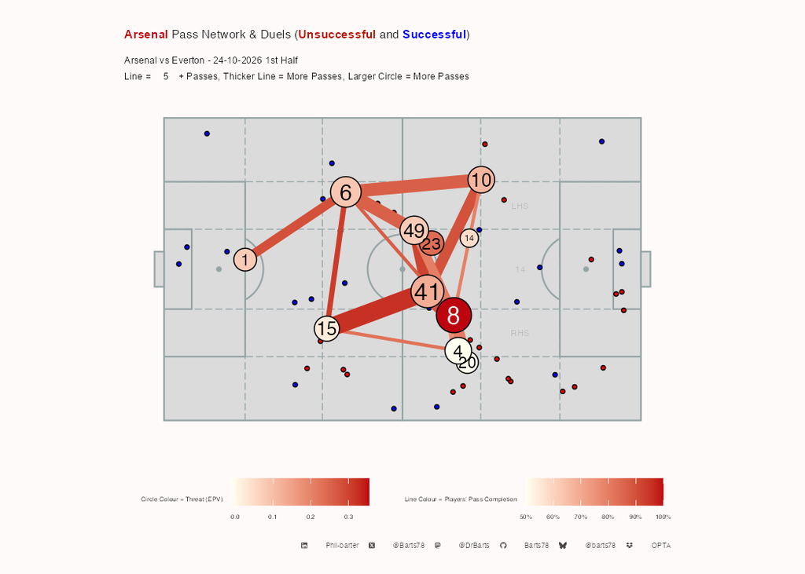

Away Pass Maps

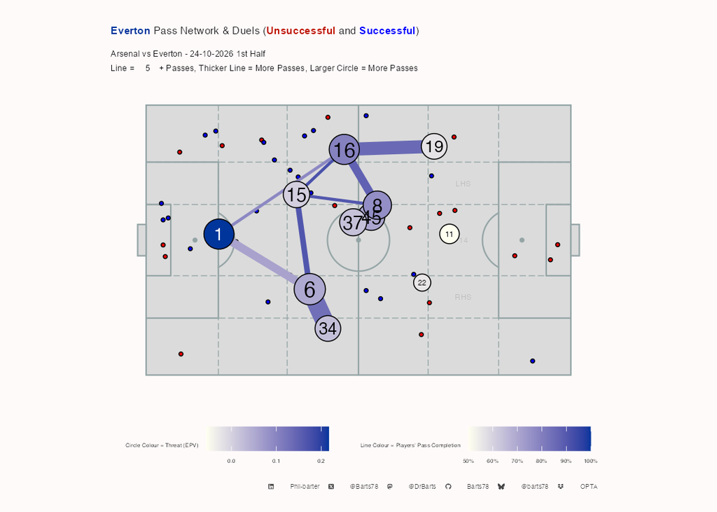

Home Pass Maps by Time

[figure not shown]

Away Pass Maps by Time

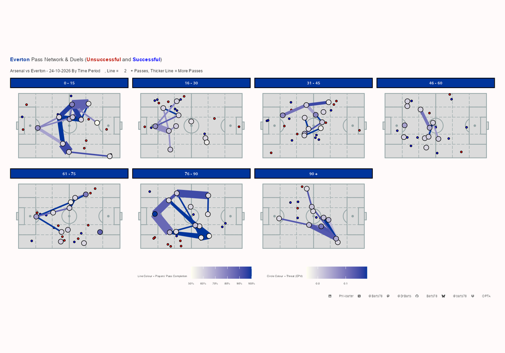

Home Attacking Pass Maps

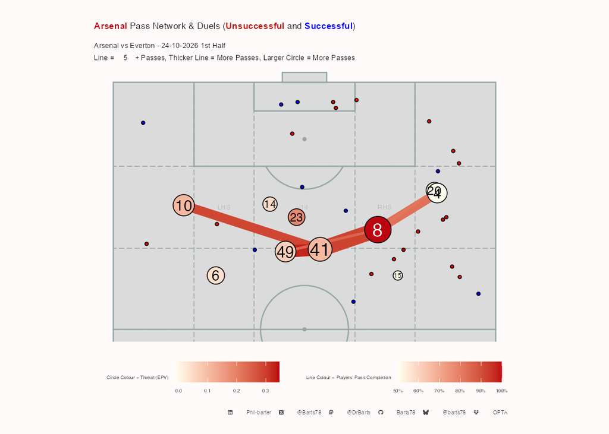

Away Attacking Pass Maps

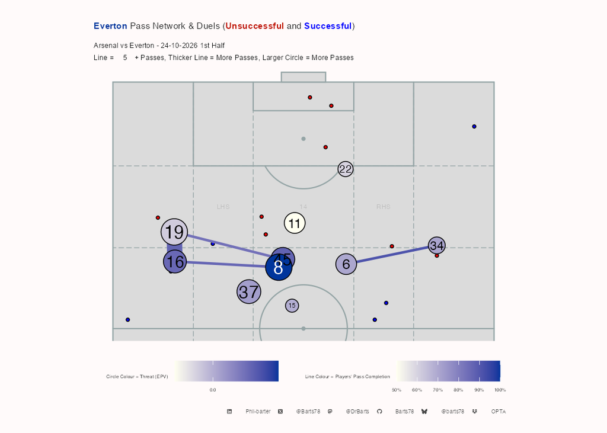

Home Attacking Pass Maps by Time

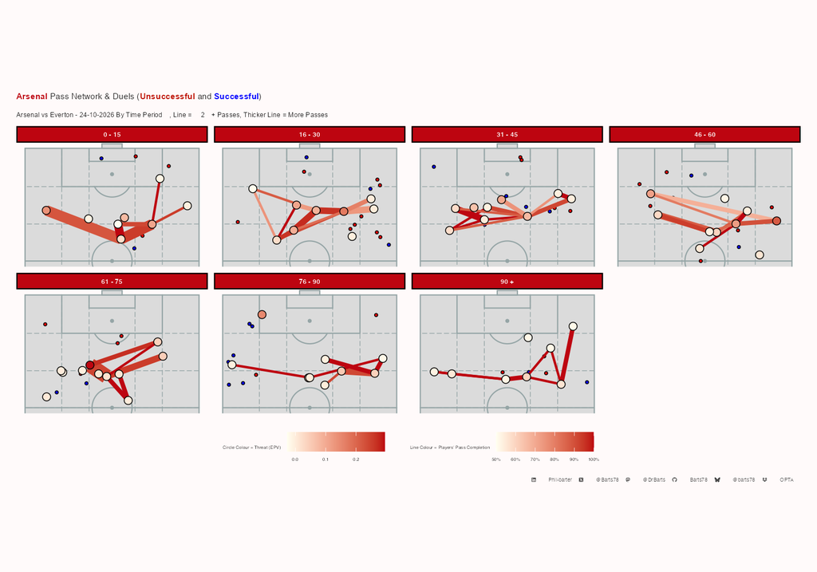

Away Attacking Pass Maps by Time

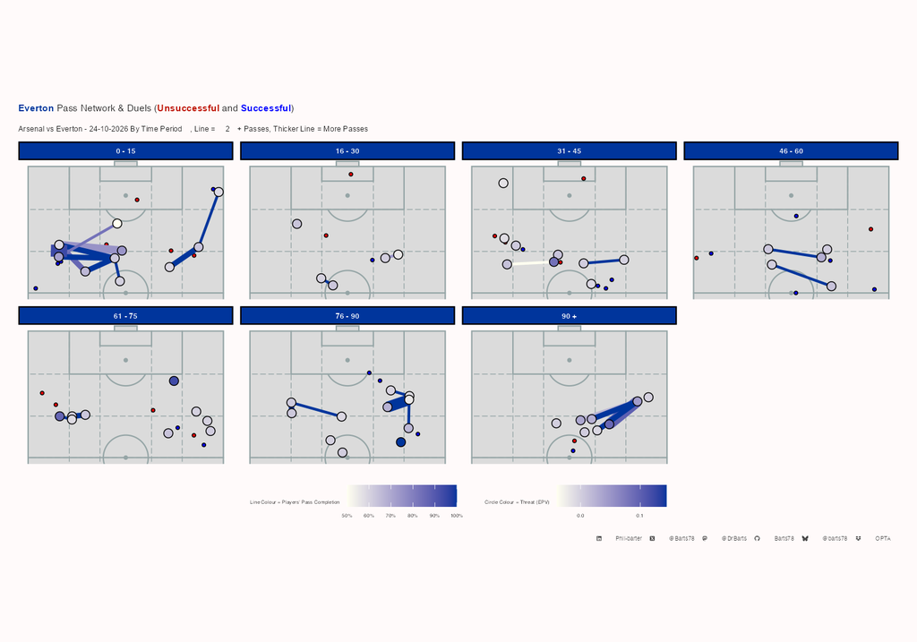

**Pass Connections by Passer**

Arsenal Open Play Passing connections

Arsenal vs Everton - 24-10-2026 | Completed passes only, min 5 per pair. Passer Completion % = all of the passer's attempts

|  | Completed Passes | % of Passer's Completions | % of Receiver's Receptions | Passer Completion % | Long Passes | Final Third Passes | PK Box Passes | Crosses | Key Passes | Prog Passes | EPV | EPV / Pass | Pass Time |
| --- | --- | --- | --- | --- | --- | --- | --- | --- | --- | --- | --- | --- | --- |
| Ben White |  |  |  |  |  |  |  |  |  |  |  |  |  |
| Ezri Konsa | 10 | 27% | 29% | 77% | 1 | 2 | 0 | 0 | 0 | 0 | 0.048 | 0.005 | 5.40 |
| Martin Ødegaard | 14 | 38% | 17% | 77% | 0 | 8 | 1 | 0 | 1 | 2 | 0.082 | 0.006 | 2.21 |
| Bruno Guimarães |  |  |  |  |  |  |  |  |  |  |  |  |  |
| Martin Ødegaard | 9 | 36% | 11% | 93% | 0 | 2 | 0 | 0 | 1 | 0 | 0.014 | 0.002 | 2.44 |
| Martín Zubimendi | 5 | 20% | 36% | 93% | 0 | 1 | 0 | 0 | 0 | 1 | 0.011 | 0.002 | 2.80 |
| Declan Rice |  |  |  |  |  |  |  |  |  |  |  |  |  |
| Eberechi Eze | 8 | 15% | 27% | 94% | 1 | 4 | 0 | 0 | 0 | 2 | 0.094 | 0.012 | 4.00 |
| Ezri Konsa | 8 | 15% | 24% | 94% | 0 | 0 | 0 | 0 | 0 | 0 | 0.011 | 0.001 | 4.12 |
| Martin Ødegaard | 12 | 23% | 14% | 94% | 0 | 1 | 0 | 0 | 0 | 1 | 0.025 | 0.002 | 4.92 |
| Myles Lewis-Skelly | 10 | 19% | 29% | 94% | 0 | 6 | 0 | 0 | 0 | 1 | 0.058 | 0.006 | 2.00 |
| Noni Madueke | 7 | 14% | 24% | 94% | 0 | 0 | 0 | 0 | 1 | 2 | 0.048 | 0.007 | 3.71 |
| Eberechi Eze |  |  |  |  |  |  |  |  |  |  |  |  |  |
| Gabriel Magalhães | 5 | 20% | 14% | 76% | 0 | 3 | 0 | 0 | 0 | 0 | 0.028 | 0.006 | 2.60 |
| Martin Ødegaard | 5 | 20% | 6% | 76% | 0 | 5 | 0 | 0 | 0 | 2 | 0.019 | 0.004 | 2.20 |
| Myles Lewis-Skelly | 6 | 24% | 18% | 76% | 0 | 2 | 0 | 0 | 0 | 1 | 0.018 | 0.003 | 2.33 |
| Ezri Konsa |  |  |  |  |  |  |  |  |  |  |  |  |  |
| Declan Rice | 11 | 29% | 24% | 95% | 0 | 0 | 0 | 0 | 0 | 1 | 0.016 | 0.001 | 4.82 |
| Martin Ødegaard | 9 | 24% | 11% | 95% | 0 | 0 | 0 | 0 | 0 | 0 | 0.009 | 0.001 | 3.67 |
| Gabriel Magalhães |  |  |  |  |  |  |  |  |  |  |  |  |  |
| David Raya | 9 | 19% | 60% | 89% | 1 | 0 | 0 | 0 | 0 | 0 | 0.013 | 0.001 | 4.78 |
| Declan Rice | 6 | 13% | 13% | 89% | 0 | 0 | 0 | 0 | 0 | 1 | 0.010 | 0.002 | 3.17 |
| Eberechi Eze | 6 | 13% | 20% | 89% | 0 | 0 | 0 | 0 | 0 | 0 | 0.033 | 0.006 | 4.33 |
| Martin Ødegaard | 8 | 17% | 10% | 89% | 0 | 1 | 0 | 0 | 0 | 3 | 0.040 | 0.005 | 2.38 |
| Mikel Merino | 5 | 11% | 17% | 89% | 0 | 1 | 0 | 0 | 0 | 2 | 0.025 | 0.005 | 3.80 |
| Martin Ødegaard |  |  |  |  |  |  |  |  |  |  |  |  |  |
| Ben White | 17 | 19% | 45% | 89% | 0 | 6 | 2 | 0 | 0 | 0 | 0.094 | 0.006 | 2.12 |
| Bruno Guimarães | 6 | 7% | 23% | 89% | 0 | 0 | 0 | 0 | 0 | 0 | 0.004 | 0.001 | 3.00 |
| Declan Rice | 11 | 12% | 24% | 89% | 0 | 1 | 0 | 0 | 0 | 2 | 0.021 | 0.002 | 3.55 |
| Eberechi Eze | 6 | 7% | 20% | 89% | 0 | 3 | 0 | 0 | 1 | 0 | 0.029 | 0.005 | 2.83 |
| Ezri Konsa | 7 | 8% | 21% | 89% | 1 | 1 | 0 | 0 | 0 | 0 | 0.021 | 0.003 | 2.57 |
| Gabriel Magalhães | 7 | 8% | 20% | 89% | 0 | 1 | 0 | 0 | 0 | 1 | 0.009 | 0.001 | 2.29 |
| Kai Havertz | 5 | 6% | 62% | 89% | 0 | 0 | 0 | 0 | 0 | 1 | 0.079 | 0.016 | 2.00 |
| Mikel Merino | 7 | 8% | 24% | 89% | 0 | 2 | 0 | 0 | 0 | 2 | 0.055 | 0.008 | 2.29 |
| Myles Lewis-Skelly | 8 | 9% | 24% | 89% | 0 | 3 | 0 | 0 | 0 | 2 | 0.055 | 0.007 | 1.75 |
| Noni Madueke | 6 | 7% | 21% | 89% | 0 | 2 | 0 | 0 | 0 | 0 | 0.048 | 0.008 | 3.33 |
| Martín Zubimendi |  |  |  |  |  |  |  |  |  |  |  |  |  |
| Martin Ødegaard | 5 | 31% | 6% | 100% | 0 | 0 | 0 | 0 | 0 | 0 | 0.006 | 0.001 | 4.00 |
| Myles Lewis-Skelly |  |  |  |  |  |  |  |  |  |  |  |  |  |
| Declan Rice | 6 | 18% | 13% | 90% | 0 | 3 | 0 | 0 | 0 | 1 | 0.026 | 0.004 | 2.50 |
| Gabriel Magalhães | 7 | 21% | 20% | 90% | 0 | 1 | 0 | 0 | 0 | 0 | 0.024 | 0.003 | 2.57 |
| Martin Ødegaard | 6 | 18% | 7% | 90% | 0 | 1 | 0 | 0 | 0 | 0 | 0.007 | 0.001 | 2.83 |
| Mikel Merino | 8 | 24% | 28% | 90% | 0 | 3 | 0 | 0 | 0 | 2 | 0.074 | 0.009 | 2.75 |
| Noni Madueke |  |  |  |  |  |  |  |  |  |  |  |  |  |
| Martin Ødegaard | 7 | 30% | 8% | 92% | 0 | 4 | 1 | 0 | 0 | 0 | 0.029 | 0.004 | 2.86 |

X @Barts78 · Bluesky @barts78 · Mastodon @DrBarts · GitHub Barts78 · LinkedIn Phil-barter · Data: Opta

**Pass Connections by Receiver**

Arsenal Open Play Passing connections

Arsenal vs Everton - 24-10-2026 | Completed passes only, min 5 per pair. Passer Completion % = all of the passer's attempts

|  | Completed Passes | % of Passer's Completions | % of Receiver's Receptions | Passer Completion % | Long Passes | Final Third Passes | PK Box Passes | Crosses | Key Passes | Prog Passes | EPV | EPV / Pass | Pass Time |
| --- | --- | --- | --- | --- | --- | --- | --- | --- | --- | --- | --- | --- | --- |
| Ezri Konsa |  |  |  |  |  |  |  |  |  |  |  |  |  |
| Ben White | 10 | 27% | 29% | 77% | 1 | 2 | 0 | 0 | 0 | 0 | 0.048 | 0.005 | 5.40 |
| Declan Rice | 8 | 15% | 24% | 94% | 0 | 0 | 0 | 0 | 0 | 0 | 0.011 | 0.001 | 4.12 |
| Martin Ødegaard | 7 | 8% | 21% | 89% | 1 | 1 | 0 | 0 | 0 | 0 | 0.021 | 0.003 | 2.57 |
| Martin Ødegaard |  |  |  |  |  |  |  |  |  |  |  |  |  |
| Ben White | 14 | 38% | 17% | 77% | 0 | 8 | 1 | 0 | 1 | 2 | 0.082 | 0.006 | 2.21 |
| Bruno Guimarães | 9 | 36% | 11% | 93% | 0 | 2 | 0 | 0 | 1 | 0 | 0.014 | 0.002 | 2.44 |
| Declan Rice | 12 | 23% | 14% | 94% | 0 | 1 | 0 | 0 | 0 | 1 | 0.025 | 0.002 | 4.92 |
| Eberechi Eze | 5 | 20% | 6% | 76% | 0 | 5 | 0 | 0 | 0 | 2 | 0.019 | 0.004 | 2.20 |
| Ezri Konsa | 9 | 24% | 11% | 95% | 0 | 0 | 0 | 0 | 0 | 0 | 0.009 | 0.001 | 3.67 |
| Gabriel Magalhães | 8 | 17% | 10% | 89% | 0 | 1 | 0 | 0 | 0 | 3 | 0.040 | 0.005 | 2.38 |
| Martín Zubimendi | 5 | 31% | 6% | 100% | 0 | 0 | 0 | 0 | 0 | 0 | 0.006 | 0.001 | 4.00 |
| Myles Lewis-Skelly | 6 | 18% | 7% | 90% | 0 | 1 | 0 | 0 | 0 | 0 | 0.007 | 0.001 | 2.83 |
| Noni Madueke | 7 | 30% | 8% | 92% | 0 | 4 | 1 | 0 | 0 | 0 | 0.029 | 0.004 | 2.86 |
| Martín Zubimendi |  |  |  |  |  |  |  |  |  |  |  |  |  |
| Bruno Guimarães | 5 | 20% | 36% | 93% | 0 | 1 | 0 | 0 | 0 | 1 | 0.011 | 0.002 | 2.80 |
| Eberechi Eze |  |  |  |  |  |  |  |  |  |  |  |  |  |
| Declan Rice | 8 | 15% | 27% | 94% | 1 | 4 | 0 | 0 | 0 | 2 | 0.094 | 0.012 | 4.00 |
| Gabriel Magalhães | 6 | 13% | 20% | 89% | 0 | 0 | 0 | 0 | 0 | 0 | 0.033 | 0.006 | 4.33 |
| Martin Ødegaard | 6 | 7% | 20% | 89% | 0 | 3 | 0 | 0 | 1 | 0 | 0.029 | 0.005 | 2.83 |
| Myles Lewis-Skelly |  |  |  |  |  |  |  |  |  |  |  |  |  |
| Declan Rice | 10 | 19% | 29% | 94% | 0 | 6 | 0 | 0 | 0 | 1 | 0.058 | 0.006 | 2.00 |
| Eberechi Eze | 6 | 24% | 18% | 76% | 0 | 2 | 0 | 0 | 0 | 1 | 0.018 | 0.003 | 2.33 |
| Martin Ødegaard | 8 | 9% | 24% | 89% | 0 | 3 | 0 | 0 | 0 | 2 | 0.055 | 0.007 | 1.75 |
| Noni Madueke |  |  |  |  |  |  |  |  |  |  |  |  |  |
| Declan Rice | 7 | 14% | 24% | 94% | 0 | 0 | 0 | 0 | 1 | 2 | 0.048 | 0.007 | 3.71 |
| Martin Ødegaard | 6 | 7% | 21% | 89% | 0 | 2 | 0 | 0 | 0 | 0 | 0.048 | 0.008 | 3.33 |
| Gabriel Magalhães |  |  |  |  |  |  |  |  |  |  |  |  |  |
| Eberechi Eze | 5 | 20% | 14% | 76% | 0 | 3 | 0 | 0 | 0 | 0 | 0.028 | 0.006 | 2.60 |
| Martin Ødegaard | 7 | 8% | 20% | 89% | 0 | 1 | 0 | 0 | 0 | 1 | 0.009 | 0.001 | 2.29 |
| Myles Lewis-Skelly | 7 | 21% | 20% | 90% | 0 | 1 | 0 | 0 | 0 | 0 | 0.024 | 0.003 | 2.57 |
| Declan Rice |  |  |  |  |  |  |  |  |  |  |  |  |  |
| Ezri Konsa | 11 | 29% | 24% | 95% | 0 | 0 | 0 | 0 | 0 | 1 | 0.016 | 0.001 | 4.82 |
| Gabriel Magalhães | 6 | 13% | 13% | 89% | 0 | 0 | 0 | 0 | 0 | 1 | 0.010 | 0.002 | 3.17 |
| Martin Ødegaard | 11 | 12% | 24% | 89% | 0 | 1 | 0 | 0 | 0 | 2 | 0.021 | 0.002 | 3.55 |
| Myles Lewis-Skelly | 6 | 18% | 13% | 90% | 0 | 3 | 0 | 0 | 0 | 1 | 0.026 | 0.004 | 2.50 |
| David Raya |  |  |  |  |  |  |  |  |  |  |  |  |  |
| Gabriel Magalhães | 9 | 19% | 60% | 89% | 1 | 0 | 0 | 0 | 0 | 0 | 0.013 | 0.001 | 4.78 |
| Mikel Merino |  |  |  |  |  |  |  |  |  |  |  |  |  |
| Gabriel Magalhães | 5 | 11% | 17% | 89% | 0 | 1 | 0 | 0 | 0 | 2 | 0.025 | 0.005 | 3.80 |
| Martin Ødegaard | 7 | 8% | 24% | 89% | 0 | 2 | 0 | 0 | 0 | 2 | 0.055 | 0.008 | 2.29 |
| Myles Lewis-Skelly | 8 | 24% | 28% | 90% | 0 | 3 | 0 | 0 | 0 | 2 | 0.074 | 0.009 | 2.75 |
| Ben White |  |  |  |  |  |  |  |  |  |  |  |  |  |
| Martin Ødegaard | 17 | 19% | 45% | 89% | 0 | 6 | 2 | 0 | 0 | 0 | 0.094 | 0.006 | 2.12 |
| Bruno Guimarães |  |  |  |  |  |  |  |  |  |  |  |  |  |
| Martin Ødegaard | 6 | 7% | 23% | 89% | 0 | 0 | 0 | 0 | 0 | 0 | 0.004 | 0.001 | 3.00 |
| Kai Havertz |  |  |  |  |  |  |  |  |  |  |  |  |  |
| Martin Ødegaard | 5 | 6% | 62% | 89% | 0 | 0 | 0 | 0 | 0 | 1 | 0.079 | 0.016 | 2.00 |

X @Barts78 · Bluesky @barts78 · Mastodon @DrBarts · GitHub Barts78 · LinkedIn Phil-barter · Data: Opta

**Away Pass Connections by Passer**

Everton Open Play Passing connections

Arsenal vs Everton - 24-10-2026 | Completed passes only, min 5 per pair. Passer Completion % = all of the passer's attempts

|  | Completed Passes | % of Passer's Completions | % of Receiver's Receptions | Passer Completion % | Long Passes | Final Third Passes | PK Box Passes | Crosses | Key Passes | Prog Passes | EPV | EPV / Pass | Pass Time |
| --- | --- | --- | --- | --- | --- | --- | --- | --- | --- | --- | --- | --- | --- |
| Harrison Armstrong |  |  |  |  |  |  |  |  |  |  |  |  |  |
| Jake O'Brien | 7 | 23% | 26% | 88% | 0 | 0 | 0 | 0 | 0 | 0 | 0.015 | 0.002 | 3.14 |
| Kiernan Dewsbury-Hall | 7 | 23% | 26% | 88% | 0 | 1 | 0 | 0 | 0 | 1 | 0.031 | 0.004 | 3.71 |
| Jake O'Brien |  |  |  |  |  |  |  |  |  |  |  |  |  |
| James Tarkowski | 5 | 18% | 16% | 97% | 0 | 0 | 0 | 0 | 0 | 0 | 0.002 | 0.000 | 3.20 |
| Jordan Pickford | 7 | 25% | 25% | 97% | 0 | 0 | 0 | 0 | 0 | 0 | 0.013 | 0.002 | 4.00 |
| Vitalii Mykolenko | 6 | 21% | 30% | 97% | 0 | 0 | 0 | 0 | 0 | 0 | 0.010 | 0.002 | 2.33 |
| James Garner |  |  |  |  |  |  |  |  |  |  |  |  |  |
| Jake O'Brien | 5 | 15% | 18% | 79% | 0 | 0 | 0 | 0 | 0 | 0 | 0.011 | 0.002 | 3.60 |
| Tyrique George | 7 | 21% | 22% | 79% | 0 | 2 | 0 | 0 | 0 | 0 | 0.025 | 0.004 | 3.00 |
| James Tarkowski |  |  |  |  |  |  |  |  |  |  |  |  |  |
| Harrison Armstrong | 5 | 12% | 16% | 91% | 0 | 1 | 0 | 0 | 0 | 2 | 0.011 | 0.002 | 2.40 |
| James Garner | 5 | 12% | 17% | 91% | 0 | 0 | 0 | 0 | 0 | 1 | 0.015 | 0.003 | 4.00 |
| Jordan Pickford | 8 | 20% | 29% | 91% | 0 | 0 | 0 | 0 | 0 | 0 | 0.011 | 0.001 | 3.38 |
| Merlin Röhl | 9 | 22% | 39% | 91% | 0 | 0 | 0 | 0 | 0 | 0 | 0.014 | 0.002 | 2.56 |
| Jordan Pickford |  |  |  |  |  |  |  |  |  |  |  |  |  |
| Jake O'Brien | 5 | 16% | 18% | 67% | 0 | 0 | 0 | 0 | 0 | 0 | 0.003 | 0.001 | 3.40 |
| James Tarkowski | 9 | 29% | 28% | 67% | 1 | 0 | 0 | 0 | 0 | 1 | 0.026 | 0.003 | 4.44 |
| Thierno Barry | 7 | 23% | 37% | 67% | 7 | 0 | 0 | 0 | 0 | 0 | 0.116 | 0.017 | 5.29 |
| Kiernan Dewsbury-Hall |  |  |  |  |  |  |  |  |  |  |  |  |  |
| Tyrique George | 10 | 34% | 31% | 94% | 1 | 5 | 0 | 0 | 1 | 0 | 0.059 | 0.006 | 7.40 |
| Vitalii Mykolenko | 5 | 17% | 25% | 94% | 0 | 0 | 0 | 0 | 0 | 0 | 0.011 | 0.002 | 3.00 |
| Merlin Röhl |  |  |  |  |  |  |  |  |  |  |  |  |  |
| Harrison Armstrong | 7 | 29% | 23% | 86% | 0 | 2 | 0 | 0 | 0 | 0 | 0.013 | 0.002 | 3.00 |
| James Tarkowski | 6 | 25% | 19% | 86% | 0 | 1 | 0 | 0 | 0 | 0 | 0.013 | 0.002 | 2.17 |
| Tyler Dibling |  |  |  |  |  |  |  |  |  |  |  |  |  |
| Hayden Hackney | 5 | 28% | 26% | 100% | 0 | 5 | 1 | 0 | 0 | 0 | 0.025 | 0.005 | 2.00 |
| Tyrique George |  |  |  |  |  |  |  |  |  |  |  |  |  |
| James Garner | 8 | 33% | 27% | 83% | 0 | 5 | 0 | 0 | 0 | 0 | 0.034 | 0.004 | 3.12 |
| Vitalii Mykolenko |  |  |  |  |  |  |  |  |  |  |  |  |  |
| Tyrique George | 8 | 35% | 25% | 85% | 0 | 1 | 0 | 0 | 0 | 0 | 0.032 | 0.004 | 3.75 |

X @Barts78 · Bluesky @barts78 · Mastodon @DrBarts · GitHub Barts78 · LinkedIn Phil-barter · Data: Opta

**Away Pass Connections by Receiver**

Everton Open Play Passing connections

Arsenal vs Everton - 24-10-2026 | Completed passes only, min 5 per pair. Passer Completion % = all of the passer's attempts

|  | Completed Passes | % of Passer's Completions | % of Receiver's Receptions | Passer Completion % | Long Passes | Final Third Passes | PK Box Passes | Crosses | Key Passes | Prog Passes | EPV | EPV / Pass | Pass Time |
| --- | --- | --- | --- | --- | --- | --- | --- | --- | --- | --- | --- | --- | --- |
| Jake O'Brien |  |  |  |  |  |  |  |  |  |  |  |  |  |
| Harrison Armstrong | 7 | 23% | 26% | 88% | 0 | 0 | 0 | 0 | 0 | 0 | 0.015 | 0.002 | 3.14 |
| James Garner | 5 | 15% | 18% | 79% | 0 | 0 | 0 | 0 | 0 | 0 | 0.011 | 0.002 | 3.60 |
| Jordan Pickford | 5 | 16% | 18% | 67% | 0 | 0 | 0 | 0 | 0 | 0 | 0.003 | 0.001 | 3.40 |
| Kiernan Dewsbury-Hall |  |  |  |  |  |  |  |  |  |  |  |  |  |
| Harrison Armstrong | 7 | 23% | 26% | 88% | 0 | 1 | 0 | 0 | 0 | 1 | 0.031 | 0.004 | 3.71 |
| James Tarkowski |  |  |  |  |  |  |  |  |  |  |  |  |  |
| Jake O'Brien | 5 | 18% | 16% | 97% | 0 | 0 | 0 | 0 | 0 | 0 | 0.002 | 0.000 | 3.20 |
| Jordan Pickford | 9 | 29% | 28% | 67% | 1 | 0 | 0 | 0 | 0 | 1 | 0.026 | 0.003 | 4.44 |
| Merlin Röhl | 6 | 25% | 19% | 86% | 0 | 1 | 0 | 0 | 0 | 0 | 0.013 | 0.002 | 2.17 |
| Jordan Pickford |  |  |  |  |  |  |  |  |  |  |  |  |  |
| Jake O'Brien | 7 | 25% | 25% | 97% | 0 | 0 | 0 | 0 | 0 | 0 | 0.013 | 0.002 | 4.00 |
| James Tarkowski | 8 | 20% | 29% | 91% | 0 | 0 | 0 | 0 | 0 | 0 | 0.011 | 0.001 | 3.38 |
| Vitalii Mykolenko |  |  |  |  |  |  |  |  |  |  |  |  |  |
| Jake O'Brien | 6 | 21% | 30% | 97% | 0 | 0 | 0 | 0 | 0 | 0 | 0.010 | 0.002 | 2.33 |
| Kiernan Dewsbury-Hall | 5 | 17% | 25% | 94% | 0 | 0 | 0 | 0 | 0 | 0 | 0.011 | 0.002 | 3.00 |
| Tyrique George |  |  |  |  |  |  |  |  |  |  |  |  |  |
| James Garner | 7 | 21% | 22% | 79% | 0 | 2 | 0 | 0 | 0 | 0 | 0.025 | 0.004 | 3.00 |
| Kiernan Dewsbury-Hall | 10 | 34% | 31% | 94% | 1 | 5 | 0 | 0 | 1 | 0 | 0.059 | 0.006 | 7.40 |
| Vitalii Mykolenko | 8 | 35% | 25% | 85% | 0 | 1 | 0 | 0 | 0 | 0 | 0.032 | 0.004 | 3.75 |
| Harrison Armstrong |  |  |  |  |  |  |  |  |  |  |  |  |  |
| James Tarkowski | 5 | 12% | 16% | 91% | 0 | 1 | 0 | 0 | 0 | 2 | 0.011 | 0.002 | 2.40 |
| Merlin Röhl | 7 | 29% | 23% | 86% | 0 | 2 | 0 | 0 | 0 | 0 | 0.013 | 0.002 | 3.00 |
| James Garner |  |  |  |  |  |  |  |  |  |  |  |  |  |
| James Tarkowski | 5 | 12% | 17% | 91% | 0 | 0 | 0 | 0 | 0 | 1 | 0.015 | 0.003 | 4.00 |
| Tyrique George | 8 | 33% | 27% | 83% | 0 | 5 | 0 | 0 | 0 | 0 | 0.034 | 0.004 | 3.12 |
| Merlin Röhl |  |  |  |  |  |  |  |  |  |  |  |  |  |
| James Tarkowski | 9 | 22% | 39% | 91% | 0 | 0 | 0 | 0 | 0 | 0 | 0.014 | 0.002 | 2.56 |
| Thierno Barry |  |  |  |  |  |  |  |  |  |  |  |  |  |
| Jordan Pickford | 7 | 23% | 37% | 67% | 7 | 0 | 0 | 0 | 0 | 0 | 0.116 | 0.017 | 5.29 |
| Hayden Hackney |  |  |  |  |  |  |  |  |  |  |  |  |  |
| Tyler Dibling | 5 | 28% | 26% | 100% | 0 | 5 | 1 | 0 | 0 | 0 | 0.025 | 0.005 | 2.00 |

X @Barts78 · Bluesky @barts78 · Mastodon @DrBarts · GitHub Barts78 · LinkedIn Phil-barter · Data: Opta

Home Passing Tree Plot

[figure not shown]

Away Passing Tree Plot

[figure not shown]

Home wave plot

[figure not shown]

Away wave plot

[figure not shown]

**Home 1st Half Pass receiving Areas**

[figure not shown]

**Home 2nd Half Pass receiving Areas**

[figure not shown]

**Home Up to 1st Sub Pass receiving Areas**

[figure not shown]

**Away 1st Half Pass receiving Areas**

[figure not shown]

**Away 2nd Half Pass receiving Areas**

[figure not shown]

**Away Up to 1st Sub Pass receiving Areas**

[figure not shown]

Home Passing chains

[figure not shown]

Away Passing Chains

[figure not shown]

**Full time**

Arsenal FT Passing Chain Length (5, 6-10, 11-15, 16 +) & Distance (m)

Arsenal vs Everton - 24-10-2026

|  | Pass Chain Length | Total Chain Passes | Max Chain Length | Average Chain Length | Percent of Teams Passes | Total Chain Distance | Max Chain Distance | Average Chain Distance | Percent of Teams Passing Distance |
| --- | --- | --- | --- | --- | --- | --- | --- | --- | --- |
|  | VLow | 182 | 5 | 3 | 38% | 2,514.89 | 128.86 | 13.80 | 36% |
|  | Low | 127 | 10 | 7 | 26% | 1,872.01 | 178.16 | 14.70 | 27% |
|  | Medium | 42 | 15 | 13 | 9% | 751.23 | 303.75 | 17.90 | 11% |
|  | High | 130 | 24 | 18 | 27% | 1,910.00 | 344.50 | 14.70 | 27% |
| Overall Totals | — | 481 | 54 | 41 | — | 7,048 | 955 | 61 | — |
| Overall Average | — | 120 | 14 | 10 | — | 1,762 | 239 | 15 | — |

X @Barts78 · Bluesky @barts78 · Mastodon @DrBarts · GitHub Barts78 · LinkedIn Phil-barter · Data: Opta

**1st Half**

Arsenal 1st Half Passing Chain Length (5, 6-10, 11-15, 16 +) & Distance (m)

Arsenal vs Everton - 24-10-2026

|  | Pass Chain Length | Total Chain Passes | Max Chain Length | Average Chain Length | Percent of Teams Passes | Total Chain Distance | Max Chain Distance | Average Chain Distance | Percent of Teams Passing Distance |
| --- | --- | --- | --- | --- | --- | --- | --- | --- | --- |
|  | VLow | 100 | 5 | 3 | 44% | 1,348.48 | 102.34 | 13.50 | 39% |
|  | Low | 54 | 10 | 8 | 24% | 839.19 | 178.16 | 15.50 | 24% |
|  | Medium | 42 | 15 | 13 | 18% | 751.23 | 303.75 | 17.90 | 22% |
|  | High | 33 | 16 | 16 | 14% | 515.30 | 275.78 | 15.60 | 15% |
| Overall Totals | — | 229 | 46 | 40 | — | 3,454 | 860 | 62 | — |
| Overall Average | — | 57 | 12 | 10 | — | 864 | 215 | 16 | — |

X @Barts78 · Bluesky @barts78 · Mastodon @DrBarts · GitHub Barts78 · LinkedIn Phil-barter · Data: Opta

**2nd Half**

Arsenal 2nd Half Passing Chain Length (5, 6-10, 11-15, 16 +) & Distance (m)

Arsenal vs Everton - 24-10-2026

|  | Pass Chain Length | Total Chain Passes | Max Chain Length | Average Chain Length | Percent of Teams Passes | Total Chain Distance | Max Chain Distance | Average Chain Distance | Percent of Teams Passing Distance |
| --- | --- | --- | --- | --- | --- | --- | --- | --- | --- |
|  | VLow | 82 | 5 | 3 | 33% | 1,166.41 | 128.86 | 14.20 | 32% |
|  | Low | 73 | 10 | 7 | 29% | 1,032.82 | 154.20 | 14.10 | 29% |
|  | High | 97 | 24 | 19 | 38% | 1,394.70 | 344.50 | 14.40 | 39% |
| Overall Totals | — | 252 | 39 | 29 | — | 3,594 | 628 | 43 | — |
| Overall Average | — | 84 | 13 | 10 | — | 1,198 | 209 | 14 | — |

X @Barts78 · Bluesky @barts78 · Mastodon @DrBarts · GitHub Barts78 · LinkedIn Phil-barter · Data: Opta

**Away Full time**

Everton FT Passing Chain Length (5, 6-10, 11-15, 16 +) & Distance (m)

Arsenal vs Everton - 24-10-2026

|  | Pass Chain Length | Total Chain Passes | Max Chain Length | Average Chain Length | Percent of Teams Passes | Total Chain Distance | Max Chain Distance | Average Chain Distance | Percent of Teams Passing Distance |
| --- | --- | --- | --- | --- | --- | --- | --- | --- | --- |
|  | VLow | 148 | 5 | 3 | 45% | 2,593.81 | 176.91 | 17.50 | 46% |
|  | Low | 108 | 10 | 8 | 33% | 1,967.47 | 222.13 | 18.20 | 35% |
|  | Medium | 35 | 12 | 11 | 11% | 512.48 | 213.26 | 14.60 | 9% |
|  | High | 40 | 23 | 20 | 12% | 590.56 | 319.75 | 14.80 | 10% |
| Overall Totals | — | 331 | 50 | 42 | — | 5,664 | 932 | 65 | — |
| Overall Average | — | 83 | 12 | 10 | — | 1,416 | 233 | 16 | — |

X @Barts78 · Bluesky @barts78 · Mastodon @DrBarts · GitHub Barts78 · LinkedIn Phil-barter · Data: Opta

**Away 1st Half**

Everton 1st Half Passing Chain Length (5, 6-10, 11-15, 16 +) & Distance (m)

Arsenal vs Everton - 24-10-2026

|  | Pass Chain Length | Total Chain Passes | Max Chain Length | Average Chain Length | Percent of Teams Passes | Total Chain Distance | Max Chain Distance | Average Chain Distance | Percent of Teams Passing Distance |
| --- | --- | --- | --- | --- | --- | --- | --- | --- | --- |
|  | VLow | 84 | 5 | 3 | 54% | 1,405.12 | 176.91 | 16.70 | 54% |
|  | Low | 31 | 10 | 8 | 20% | 579.14 | 181.19 | 18.70 | 22% |
|  | Medium | 24 | 12 | 12 | 15% | 365.28 | 213.26 | 15.20 | 14% |
|  | High | 17 | 16 | 16 | 11% | 270.81 | 278.64 | 15.90 | 10% |
| Overall Totals | — | 156 | 43 | 39 | — | 2,620 | 850 | 66 | — |
| Overall Average | — | 39 | 11 | 10 | — | 655 | 212 | 17 | — |

X @Barts78 · Bluesky @barts78 · Mastodon @DrBarts · GitHub Barts78 · LinkedIn Phil-barter · Data: Opta

**Away 2nd Half**

Everton 2nd Half Passing Chain Length (5, 6-10, 11-15, 16 +) & Distance (m)

Arsenal vs Everton - 24-10-2026

|  | Pass Chain Length | Total Chain Passes | Max Chain Length | Average Chain Length | Percent of Teams Passes | Total Chain Distance | Max Chain Distance | Average Chain Distance | Percent of Teams Passing Distance |
| --- | --- | --- | --- | --- | --- | --- | --- | --- | --- |
|  | VLow | 64 | 5 | 3 | 37% | 1,188.69 | 102.43 | 18.60 | 39% |
|  | Low | 77 | 10 | 9 | 44% | 1,388.33 | 222.13 | 18.00 | 46% |
|  | Medium | 11 | 11 | 11 | 6% | 147.20 | 147.20 | 13.40 | 5% |
|  | High | 23 | 23 | 23 | 13% | 319.75 | 319.75 | 13.90 | 11% |
| Overall Totals | — | 175 | 49 | 46 | — | 3,044 | 792 | 64 | — |
| Overall Average | — | 44 | 12 | 12 | — | 761 | 198 | 16 | — |

X @Barts78 · Bluesky @barts78 · Mastodon @DrBarts · GitHub Barts78 · LinkedIn Phil-barter · Data: Opta

**Home Z14 RS By Half**

[figure not shown]

**Home Z14 RS By Game Period**

[figure not shown]

**Away Z14 RS By Half**

[figure not shown]

**Away Z14 RS By Game Period**

[figure not shown]

**Home Long Passes By half**

[figure not shown]

**Home Long Passes By Game Period**

[figure not shown]

**Away Long Passes By Half**

[figure not shown]

**Away Long Passes By Game period**

[figure not shown]

Set-Piece Summary

**Set Pieces**

Arsenal vs Everton - 24-10-2026

|  | Arsenal | Everton |
| --- | --- | --- |
| Corners |  |  |
| Corners taken | 12 | 3 |
| Short | 1 | 0 |
| Direct | 11 | 3 |
| Direct - first contact won | 3 (27%) | 0 (0%) |
| Free kicks |  |  |
| Free kicks (passes) | 14 | 11 |
| Into final third / box | 2 | 6 |
| Into box | 2 | 3 |
| Throw-ins |  |  |
| Throw-ins | 21 | 8 |
| Retained (first touch) | 95% | 88% |
| Shots by situation |  |  |
| Open-play shots | 14 | 8 |
| Open-play xG | 1.07 | 0.63 |
| Open-play goals | 1 | 0 |
| Set-piece shots | 6 | 0 |
| Set-piece xG | 0.91 | 0.00 |
| Set-piece goals | 1 | 0 |
| Penalties | 0 | 0 |
| Penalty xG | 0.00 | 0.00 |
| Set-piece share of xG | 46% | 0% |

First contact: the team that touches the ball first after the delivery (aerial duels go to the winner). Throw-ins retained = first touch by the taking team.  
X @Barts78 · Bluesky @barts78 · Mastodon @DrBarts · GitHub Barts78 · LinkedIn Phil-barter · Data: Opta

**Corners**

[figure not shown]

**Free Kicks**

[figure not shown]

**Corners**

[figure not shown]

**Free Kicks**

[figure not shown]

**Sequence Map**

[figure not shown]

**Sequence Table**

**Arsenal - Shot-Creating Sequences**

Arsenal vs Everton - 24-10-2026

| Min | Shooter | Result | xG | Situation | Started by | Started from | Start zone | Passes | Duration (s) |
| --- | --- | --- | --- | --- | --- | --- | --- | --- | --- |
| 4' | Rice | Blocked | 0.04 | Open play | Merino | Throw-in | Att third, Left wing | 8 | 17 |
| 6' | Konsa | Blocked | 0.10 | Set piece | Rice | Corner | Att third, Left wing | 1 | 3 |
| 7' | Magalhães | Saved | 0.28 | Set piece | Ødegaard | Corner | Att third, Right wing | 1 | 1 |
| 7' | Konsa | Goal | 0.13 | Set piece | Gyökeres | Open-play regain | Att third, Central | 0 | 1 |
| 20' | Ødegaard | Blocked | 0.06 | Open play | Madueke | Open-play regain | Att third, Central | 0 | 1 |
| 22' | Merino | Blocked | 0.22 | Set piece | Rice | Corner | Att third, Left wing | 1 | 2 |
| 24' | Eze | Off target | 0.03 | Open play | Magalhães | Open-play regain | Mid third, Left half-space | 5 | 16 |
| 28' | Madueke | Off target | 0.06 | Open play | White | Throw-in | Att third, Right wing | 4 | 11 |
| 29' | Merino | Blocked | 0.12 | Open play | Merino | Open-play regain | Att third, Central | 0 | 0 |
| 30' | Madueke | Off target | 0.03 | Open play | White | Throw-in | Att third, Right wing | 6 | 20 |
| 35' | Eze | Blocked | 0.02 | Open play | Rice | Free kick | Att third, Left wing | 4 | 14 |
| 40' | Ødegaard | Blocked | 0.13 | Open play | Eze | Open-play regain | Def third, Left half-space | 4 | 17 |
| 45+3' | Merino | Off target | 0.10 | Set piece | Rice | Free kick | Att third, Right half-space | 1 | 2 |
| 51' | Ødegaard | Saved | 0.02 | Open play | Rice | Corner | Att third, Left wing | 1 | 8 |
| 54' | Madueke | Blocked | 0.08 | Set piece | White | Throw-in | Att third, Right wing | 2 | 5 |
| 58' | Merino | Blocked | 0.04 | Open play | White | Throw-in | Mid third, Right wing | 5 | 19 |
| 66' | Merino | Blocked | 0.05 | Open play | Magalhães | Open-play regain | Mid third, Left half-space | 3 | 17 |
| 68' | Magalhães | Goal | 0.42 | Open play | Rice | Corner | Att third, Left wing | 10 | 27 |
| 90+1' | Ødegaard | Off target | 0.02 | Open play | Raya | Keeper | Def third, Central | 20 | 79 |
| 90+5' | Ødegaard | Off target | 0.03 | Open play | Zubimendi | Open-play regain | Mid third, Central | 5 | 17 |

X @Barts78 · Bluesky @barts78 · Mastodon @DrBarts · GitHub Barts78 · LinkedIn Phil-barter · Data: Opta

**Sequence Map**

[figure not shown]

**Sequence Table**

**Everton - Shot-Creating Sequences**

Arsenal vs Everton - 24-10-2026

| Min | Shooter | Result | xG | Situation | Started by | Started from | Start zone | Passes | Duration (s) |
| --- | --- | --- | --- | --- | --- | --- | --- | --- | --- |
| 11' | Garner | Saved | 0.03 | Open play | Armstrong | Open-play regain | Att third, Central | 2 | 4 |
| 17' | George | Blocked | 0.03 | Open play | Armstrong | Open-play regain | Mid third, Left half-space | 20 | 68 |
| 44' | Barry | Saved | 0.32 | Open play | Barry | Open-play regain | Att third, Central | 0 | 0 |
| 76' | Armstrong | Off target | 0.05 | Open play | Pickford | Free kick | Def third, Central | 9 | 24 |
| 83' | Dewsbury-Hall | Off target | 0.06 | Open play | Garner | Open-play regain | Def third, Left wing | 16 | 59 |
| 89' | Hackney | Saved | 0.02 | Open play | Hackney | Open-play regain | Mid third, Central | 3 | 13 |
| 90+5' | Barry | Blocked | 0.06 | Open play | O'Brien | Open-play regain | Mid third, Right half-space | 3 | 8 |
| 90+8' | Alcaraz | Off target | 0.06 | Open play | Hackney | Open-play regain | Mid third, Left half-space | 4 | 15 |

X @Barts78 · Bluesky @barts78 · Mastodon @DrBarts · GitHub Barts78 · LinkedIn Phil-barter · Data: Opta

Entries by Channel

**Box and Final-Third Entries (open play)**

Arsenal vs Everton - 24-10-2026

|  | Box entries Passes | Box entries Carries | Box entries Total | Box entries Success % | Final-third entries Passes | Final-third entries Carries | Final-third entries Total | Final-third entries Success % |
| --- | --- | --- | --- | --- | --- | --- | --- | --- |
| Arsenal |  |  |  |  |  |  |  |  |
| Left wing | 6 | 3 | 9 | 33% | 6 | 2 | 8 | 62% |
| Left half-space | 5 | 0 | 5 | 40% | 10 | 0 | 10 | 70% |
| Central | 10 | 3 | 13 | 62% | 23 | 8 | 31 | 77% |
| Right half-space | 4 | 2 | 6 | 50% | 11 | 4 | 15 | 80% |
| Right wing | 5 | 0 | 5 | 40% | 13 | 2 | 15 | 80% |
| Total | 30 | 8 | 38 | 47% | 63 | 16 | 79 | 76% |
| Everton |  |  |  |  |  |  |  |  |
| Left wing | 5 | 2 | 7 | 71% | 8 | 3 | 11 | 73% |
| Left half-space | 3 | 0 | 3 | 67% | 7 | 3 | 10 | 70% |
| Central | 1 | 1 | 2 | 50% | 13 | 2 | 15 | 80% |
| Right half-space | 4 | 0 | 4 | 25% | 8 | 2 | 10 | 90% |
| Right wing | 5 | 1 | 6 | 17% | 6 | 5 | 11 | 64% |
| Total | 18 | 4 | 22 | 45% | 42 | 15 | 57 | 75% |

Channel = where the pass or carry started. Left/right from the attacking team's view. Set pieces excluded.  
X @Barts78 · Bluesky @barts78 · Mastodon @DrBarts · GitHub Barts78 · LinkedIn Phil-barter · Data: Opta

**Box**

[figure not shown]

**Final Third**

[figure not shown]

**Box**

[figure not shown]

**Final Third**

[figure not shown]

**Match Stats**

**Passing stats**

Arsenal vs Everton - 24-10-2026

|  | Name | Mins | % of Team Possession | xA | xT | Attempted Passes | Successful Passes | Pass Success % | Assists | BCs | Key Passes | Long Ps | Final 3rd P | Prog Ps | PK Box P | Pass Received | PPs Received | KPs Recieved | Recieveing Suc | EPV Recieved | EPV Created | % of Team EPV |
| --- | --- | --- | --- | --- | --- | --- | --- | --- | --- | --- | --- | --- | --- | --- | --- | --- | --- | --- | --- | --- | --- | --- |
| Keeper | David Raya | 101 | 0.05 | 0 | 0.01 | 22 | 14 | 0.64 | 0 | 0 | 0 | 10 | 0 | 0 | 0 | 19 | 0 | 0 | 0.789473684210526 | 0.372 | 0.032 | 0.01 |
| Defender | Ben White | 101 | 0.1 | 0 | 0.45 | 48 | 37 | 0.77 | 1 | 0 | 3 | 4 | 20 | 6 | 4 | 50 | 2 | 0 | 0.76 | 0.401 | 0.451 | 0.13 |
| Defender | Ezri Konsa | 101 | 0.07 | 0 | 0.01 | 40 | 38 | 0.95 | 0 | 1 | 0 | 2 | 0 | 2 | 0 | 39 | 0 | 0 | 0.871794871794872 | 0.149 | 0.066 | 0.02 |
| Defender | Gabriel Magalhães | 101 | 0.1 | 0.43 | 0.08 | 53 | 47 | 0.89 | 0 | 1 | 0 | 5 | 3 | 6 | 0 | 48 | 1 | 0 | 0.729166666666667 | 0.264 | 0.171 | 0.05 |
| Defender | Myles Lewis-Skelly | 70 | 0.08 | 0 | 0.18 | 38 | 34 | 0.89 | 0 | 0 | 1 | 3 | 10 | 4 | 1 | 39 | 5 | 0 | 0.871794871794872 | 0.284 | 0.247 | 0.07 |
| Defender | Riccardo Calafiori | 31 | 0.02 | 0 | 0.01 | 10 | 7 | 0.7 | 0 | 0 | 0 | 0 | 2 | 0 | 0 | 10 | 2 | 0 | 0.8 | 0.045 | 0.023 | 0.01 |
| Midfielder | Martin Ødegaard | 101 | 0.16 | 0.02 | 0.58 | 99 | 88 | 0.89 | 0 | 0 | 2 | 3 | 27 | 12 | 4 | 85 | 8 | 2 | 0.976470588235294 | 0.261 | 0.706 | 0.2 |
| Midfielder | Noni Madueke | 101 | 0.07 | 0.02 | 0.11 | 26 | 24 | 0.92 | 0 | 0 | 2 | 0 | 16 | 3 | 2 | 33 | 5 | 2 | 0.909090909090909 | 0.23 | 0.163 | 0.05 |
| Midfielder | Declan Rice | 82 | 0.1 | 0.01 | 0.69 | 55 | 52 | 0.95 | 0 | 0 | 4 | 3 | 13 | 7 | 0 | 50 | 5 | 1 | 0.92 | 0.184 | 0.921 | 0.27 |
| Midfielder | Eberechi Eze | 82 | 0.07 | 0.03 | 0.12 | 33 | 25 | 0.76 | 0 | 0 | 1 | 2 | 22 | 4 | 7 | 31 | 5 | 2 | 0.967741935483871 | 0.288 | 0.201 | 0.06 |

[output cut: 6 more lines]

X @Barts78 · Bluesky @barts78 · Mastodon @DrBarts · GitHub Barts78 · LinkedIn Phil-barter · Data: Opta

**Touches and Carries**

Arsenal vs Everton - 24-10-2026

|  | Name | Mins | Touches | Def 3rd | Mid 3rd | Final 3rd | PK Box | Total / Min | Def 3rd % TT | Mid Third % TT | Final 3rd % TT | PK Box % TT | Carries | % Carries Prog | % Carries F 3rd | % Carries D Prog | Total Dribbles | Dribbles Won | Dribbles Lost | Dribble Success |
| --- | --- | --- | --- | --- | --- | --- | --- | --- | --- | --- | --- | --- | --- | --- | --- | --- | --- | --- | --- | --- |
| Keeper | David Raya | 101 | 35 | 33 | 2 | 0 | 0 | 0.346534653465347 | 0.942857142857143 | 0.0571428571428571 | 0 | 0 | 11 | 0 | 0 | 0 | 0 | 0 | 0 | 0 |
| Defender | Ben White | 101 | 70 | 13 | 26 | 31 | 5 | 0.693069306930693 | 0.185714285714286 | 0.371428571428571 | 0.442857142857143 | 0.0714285714285714 | 11 | 0 | 0.0909090909090909 | 0 | 1 | 0 | 1 | 0 |
| Defender | Ezri Konsa | 101 | 51 | 26 | 20 | 5 | 4 | 0.504950495049505 | 0.509803921568627 | 0.392156862745098 | 0.0980392156862745 | 0.0784313725490196 | 12 | 0.0833333333333333 | 0 | 0.0926134481616429 | 0 | 0 | 0 | 0 |
| Defender | Gabriel Magalhães | 101 | 72 | 28 | 39 | 5 | 2 | 0.712871287128713 | 0.388888888888889 | 0.541666666666667 | 0.0694444444444444 | 0.0277777777777778 | 13 | 0.153846153846154 | 0.0769230769230769 | 0.177913652971441 | 0 | 0 | 0 | 0 |
| Defender | Myles Lewis-Skelly | 70 | 56 | 13 | 24 | 19 | 3 | 0.8 | 0.232142857142857 | 0.428571428571429 | 0.339285714285714 | 0.0535714285714286 | 6 | 0.166666666666667 | 0.666666666666667 | 0.121591273660571 | 0 | 0 | 0 | 0 |
| Defender | Riccardo Calafiori | 31 | 15 | 2 | 10 | 3 | 0 | 0.483870967741935 | 0.133333333333333 | 0.666666666666667 | 0.2 | 0 | 0 | 0 | Inf | 0 | 0 | 0 | 0 | 0 |
| Midfielder | Martin Ødegaard | 101 | 116 | 12 | 61 | 43 | 6 | 1.14851485148515 | 0.103448275862069 | 0.525862068965517 | 0.370689655172414 | 0.0517241379310345 | 17 | 0.294117647058824 | 0.588235294117647 | 0.28764532458141 | 2 | 1 | 1 | 0.5 |
| Midfielder | Noni Madueke | 101 | 52 | 6 | 10 | 36 | 6 | 0.514851485148515 | 0.115384615384615 | 0.192307692307692 | 0.692307692307692 | 0.115384615384615 | 2 | 0 | 1 | 0 | 8 | 3 | 5 | 0.375 |
| Midfielder | Declan Rice | 82 | 70 | 8 | 39 | 23 | 0 | 0.853658536585366 | 0.114285714285714 | 0.557142857142857 | 0.328571428571429 | 0 | 16 | 0.3125 | 0.4375 | 0.365588475129111 | 0 | 0 | 0 | 0 |
| Midfielder | Eberechi Eze | 82 | 49 | 4 | 11 | 34 | 11 | 0.597560975609756 | 0.0816326530612245 | 0.224489795918367 | 0.693877551020408 | 0.224489795918367 | 3 | 0 | 1.33333333333333 | 0 | 4 | 1 | 3 | 0.25 |

[output cut: 6 more lines]

X @Barts78 · Bluesky @barts78 · Mastodon @DrBarts · GitHub Barts78 · LinkedIn Phil-barter · Data: Opta

**Shooting stats**

Arsenal vs Everton - 24-10-2026

|  | Name | Mins | Total Shots | SoT | 6 yard box | PK Box Shot | Out Box Shots | Blocked Shot | Goals | xG | xGOT | xG/Shot | Shot Accuracy | Shot Quality |
| --- | --- | --- | --- | --- | --- | --- | --- | --- | --- | --- | --- | --- | --- | --- |
| Keeper | David Raya | 101 | 0 | 0 | 0 | 0 | 0 | 0 | 0 | 0 | 0 | 0 | 0 | 0 |
| Defender | Ben White | 101 | 0 | 0 | 0 | 0 | 0 | 0 | 0 | 0 | 0 | 0 | 0 | 0 |
| Defender | Ezri Konsa | 101 | 2 | 1 | 2 | 2 | 0 | 1 | 1 | 0.23 | 0.42 | 0.115 | 0.5 | 0.826086956521739 |
| Defender | Gabriel Magalhães | 101 | 2 | 2 | 2 | 2 | 0 | 0 | 1 | 0.7 | 1.83 | 0.35 | 1 | 1.61428571428571 |
| Defender | Myles Lewis-Skelly | 70 | 0 | 0 | 0 | 0 | 0 | 0 | 0 | 0 | 0 | 0 | 0 | 0 |
| Defender | Riccardo Calafiori | 31 | 0 | 0 | 0 | 0 | 0 | 0 | 0 | 0 | 0 | 0 | 0 | 0 |
| Midfielder | Martin Ødegaard | 101 | 5 | 1 | 0 | 1 | 4 | 2 | 0 | 0.26 | 0.01 | 0.052 | 0.2 | -0.961538461538461 |
| Midfielder | Noni Madueke | 101 | 3 | 0 | 0 | 3 | 0 | 1 | 0 | 0.17 | 0 | 0.0566666666666667 | 0 | -1 |
| Midfielder | Declan Rice | 82 | 1 | 0 | 0 | 0 | 1 | 1 | 0 | 0.04 | 0 | 0.04 | 0 | -1 |
| Midfielder | Eberechi Eze | 82 | 2 | 0 | 0 | 1 | 1 | 1 | 0 | 0.05 | 0 | 0.025 | 0 | -1 |

[output cut: 6 more lines]

X @Barts78 · Bluesky @barts78 · Mastodon @DrBarts · GitHub Barts78 · LinkedIn Phil-barter · Data: Opta

**Defensive stats**

Arsenal vs Everton - 24-10-2026